# Projet 6 - Notebook - Classifiez automatiquement des biens de consommation

L'objet de ce projet est d'examiner la faisabilité de classifier de manière non supervisée la liste des produits d'un site de e-commerce à partir de leur description sous forme de texte ou d'image.

Les données sont regroupées dans un [fichier csv](https://s3-eu-west-1.amazonaws.com/static.oc-static.com/prod/courses/files/Parcours_data_scientist/Projet+-+Textimage+DAS+V2/Dataset+projet+pre%CC%81traitement+textes+images.zip).

Ce projet est mené en langage Python, utilisant globalement les librairies Numpy, Pandas, et Matplotlib, et de manière spécifique pour le traitement du langage et d'image : 1) Traitement du langage naturel :

```
- NLTK pour le preprocessing.
- Scikit-learn pour le bag of words et les décompositions LDA et NMF.
- Gensim pour le word embeddings.
- Tensorflow et Keras s'agissant des réseaux de neurones (W2V, BERT, USE).
```

2) Traitement des images :

```
- OpenCV pour l'implémentation de SIFT.
- Tensorflow et Keras pour les CNN.
```

3) Pour l'ensemble des traitements, nous utilisons Scikit-learn pour la métrique ARI, la réduction de dimensionnalité (t-SNE) et les algorithmes de clustering KMeans et GMM.

Les versions sont indiquées dans ce notebook. L'IDE utilisé est Pycharm.

## Sommaire

1. Initialisations
2. Prise de connaissance des données
   1. Lecture des fichiers et identification des informations clés
   2. Analyse de l'arborescence produit et fixation des catégories cibles
3. Evaluation et visualisation du clustering
   1. Fonction de réduction de dimensionnalité
   2. Fonction de clustering
   3. Fonction d'évaluation du clustering
   4. Matrice de confusion et ordination des labels prédits
   5. Fonction de prédiction des labels de cluster
   6. Fonction de visualisation des clusters
   7. Fonction de recherche sur grille
   8. Fonction d'affichage graphique du résultat de la recherche sur grille
4. Preprocessing du texte
   1. Fonctions de preprocessing de texte
   2. Preprocessing des descriptions des produits
   3. Détermination des labels de catégorie de produit
5. Approche de clustering de type Bag of Words
   1. Fonctions communes
   2. Comptage simple de mots
   3. TF-IDF
6. Approche par la détermination des sujets clés
   1. Latent Dirichlet Allocation (LDA)
   2. Factorisation de matrice non-négative (NMF)
7. Approche de type word embedding avec Word2Vec
   1. Fonctions
   2. Word2Vec
8. Approche de type word/sentence embedding avec BERT
   1. Fonctions de BERT
   2. BERT
9. Approche de type word/sentence embedding avec USE
   1. Fonctions de USE
   2. USE
10. Conclusion sur le clustering textuel
11. Approche CV avec SIFT
    1. Extraction des features
    2. Création du bag of visual words
    3. Classification
12. Approche CV avec CNN
    1. Fonction d'extraction des features à partir d'un modèle pré-entrainé
    2. Fonction pour la recherche sur grille
    3. Clustering avec recherche sur grille
13. Conclusion sur le clustering des images
14. Clustering combiné du texte et des images
    1. Récupération des features des meilleurs modèles
    2. Combinaison par concaténation des features
    3. Combinaison des probabilités de label des modèles
15. Conclusion sur le projet

# 1 - Initialisations

```python
# Import des librairies
import numpy as np
import pandas as pd
import matplotlib as mpl
import matplotlib.pyplot as plt
import seaborn as sns

import sys
from tqdm.notebook import tqdm

# Fonctions support du projet
import P6_fonctions as fct

# Mesure du temps de calcul:
#import timeit
#start_time = timeit.default_timer()
# ... code dont on veut mesurer la durée ...
#elapsed = timeit.default_timer() - start_time
#print(f"Temps de calcul {fct.elapsed_format(elapsed)}")

# Pour afficher les graphiques dans le Notebook
%matplotlib inline
# Pour afficher les graphiques dans une fenêtre matplotlib
#%matplotlib qt

# Display options
from IPython.display import display, display_html, display_png, display_svg, Image
pd.set_option('display.max_rows', 200)
pd.set_option('display.max_columns', 200)
pd.set_option('display.width', 1000)
pd.set_option('display.max_colwidth', 199)
pd.set_option('display.colheader_justify', 'center')
pd.set_option('display.precision', 3)

# Colorama
from colorama import Fore, Back, Style
# Fore: BLACK, RED, GREEN, YELLOW, BLUE, MAGENTA, CYAN, WHITE, RESET.
# Back: BLACK, RED, GREEN, YELLOW, BLUE, MAGENTA, CYAN, WHITE, RESET.
# Style: DIM, NORMAL, BRIGHT, RESET_ALL

# Affiche les versions de Python et packages généraux utilisés
print(Fore.BLACK + Style.BRIGHT + Back.WHITE
      + 'Versions de Python et des principales librairies utilisées :\n' +
      Style.RESET_ALL)
print('- Python : ' + sys.version)
print('- Numpy : ' + np.__version__)
print('- Pandas : ' + pd.__version__)
print('- Matplotlib : ' + mpl.__version__)
print('- Seaborn : ' + sns.__version__)

# Version de jupyter
!jupyter --version
```

```
Versions de Python et des principales librairies utilisées :

- Python : 3.9.12 (main, Apr  4 2022, 05:22:27) [MSC v.1916 64 bit (AMD64)]
- Numpy : 1.23.0
- Pandas : 1.4.2
- Matplotlib : 3.5.2
- Seaborn : 0.11.2
Selected Jupyter core packages...
IPython          : 8.4.0
ipykernel        : 6.15.0
ipywidgets       : 7.7.1
jupyter_client   : 7.3.4
jupyter_core     : 4.10.0
jupyter_server   : 1.13.5
jupyterlab       : 3.2.9
nbclient         : 0.6.4
nbconvert        : 6.5.0
nbformat         : 5.4.0
notebook         : 6.4.12
qtconsole        : 5.3.1
traitlets        : 5.3.0
```

*retour sommaire*

## 2 - Prise de connaissance des données

### 2.1 - Lecture des fichiers et identification des informations clés

Le fichier comporte 1050 produits caractérisés par 15 variables, parmi lesquelles les variables clés pour notre projet sont :

- 'product_category_tree' qui indique l'arborescence catégorielle à laquelle chaque produit appartient,
- 'image' qui donne la visualisation de chaque produit sous forme d'image jpg,
- 'description' qui donne la description de chaque produit sous forme de texte.

Ces 3 variables sont toutes renseignées et nous disposons donc d'un jeu de 1050 produits à partir duquel nous allons effectuer la catégorisation non supervisée.

```python
# Variables de chemin pour les fichiers
data_path = './P6_data/Flipkart/'
fig_path = './P6_fig/'

# Chargement et prise de connaissance du jeu de données
data_fk = pd.read_csv(data_path + "flipkart_com-ecommerce_sample_1050.csv")
display(data_fk.head())
display(data_fk.info())
```

|  | uniq_id | crawl_timestamp | product_url | product_name | product_category_tree | pid | retail_price | discounted_price | image | is_FK_Advantage_product | description | product_rating | overall_rating | brand | product_specifications |
| --- | --- | --- | --- | --- | --- | --- | --- | --- | --- | --- | --- | --- | --- | --- | --- |
| 0 | 55b85ea15a1536d46b7190ad6fff8ce7 | 2016-04-30 03:22:56 +0000 | http://www.flipkart.com/elegance-polyester-multicolor-abstract-eyelet-door-curtain/p/itmeg7bkzdgthcts?pid=CRNEG7BKMFFYHQ8Z | Elegance Polyester Multicolor Abstract Eyelet Door Curtain | ["Home Furnishing >> Curtains & Accessories >> Curtains >> Elegance Polyester Multicolor Abstract Eyelet Do..."] | CRNEG7BKMFFYHQ8Z | 1,899.00 | 899.00 | 55b85ea15a1536d46b7190ad6fff8ce7.jpg | False | Key Features of Elegance Polyester Multicolor Abstract Eyelet Door Curtain Floral Curtain,Elegance Polyester Multicolor Abstract Eyelet Door Curtain (213 cm in Height, Pack of 2) Price: Rs. 899 T... | No rating available | No rating available | Elegance | {"product_specification"=>[{"key"=>"Brand", "value"=>"Elegance"}, {"key"=>"Designed For", "value"=>"Door"}, {"key"=>"Type", "value"=>"Eyelet"}, {"key"=>"Model Name", "value"=>"Abstract Polyester ... |
| 1 | 7b72c92c2f6c40268628ec5f14c6d590 | 2016-04-30 03:22:56 +0000 | http://www.flipkart.com/sathiyas-cotton-bath-towel/p/itmegfzhxbyucwgn?pid=BTWEGFZHGBXPHZUH | Sathiyas Cotton Bath Towel | ["Baby Care >> Baby Bath & Skin >> Baby Bath Towels >> Sathiyas Baby Bath Towels >> Sathiyas Cotton Bath Towel (3 Bath Towel, Red, Y..."] | BTWEGFZHGBXPHZUH | 600.00 | 449.00 | 7b72c92c2f6c40268628ec5f14c6d590.jpg | False | Specifications of Sathiyas Cotton Bath Towel (3 Bath Towel, Red, Yellow, Blue) Bath Towel Features Machine Washable Yes Material Cotton Design Self Design General Brand Sathiyas Type Bath Towel G... | No rating available | No rating available | Sathiyas | {"product_specification"=>[{"key"=>"Machine Washable", "value"=>"Yes"}, {"key"=>"Material", "value"=>"Cotton"}, {"key"=>"Design", "value"=>"Self Design"}, {"key"=>"Brand", "value"=>"Sathiyas"}, {... |
| 2 | 64d5d4a258243731dc7bbb1eef49ad74 | 2016-04-30 03:22:56 +0000 | http://www.flipkart.com/eurospa-cotton-terry-face-towel-set/p/itmeg6shbrpubhca?pid=BTWEG6SHXTDB2A2Y | Eurospa Cotton Terry Face Towel Set | ["Baby Care >> Baby Bath & Skin >> Baby Bath Towels >> Eurospa Baby Bath Towels >> Eurospa Cotton Terry Face Towel Set (20 PIECE FA..."] | BTWEG6SHXTDB2A2Y | NaN | NaN | 64d5d4a258243731dc7bbb1eef49ad74.jpg | False | Key Features of Eurospa Cotton Terry Face Towel Set Size: small Height: 9 inch GSM: 360,Eurospa Cotton Terry Face Towel Set (20 PIECE FACE TOWEL SET, Assorted) Price: Rs. 299 Eurospa brings to yo... | No rating available | No rating available | Eurospa | {"product_specification"=>[{"key"=>"Material", "value"=>"Cotton Terry"}, {"key"=>"Design", "value"=>"SHUVAM"}, {"key"=>"Brand", "value"=>"Eurospa"}, {"key"=>"GSM", "value"=>"360"}, {"key"=>"Type"... |
| 3 | d4684dcdc759dd9cdf41504698d737d8 | 2016-06-20 08:49:52 +0000 | http://www.flipkart.com/santosh-royal-fashion-cotton-printed-king-sized-double-bedsheet/p/itmejt9uaqahahuf?pid=BDSEJT9UQWHDUBH4 | SANTOSH ROYAL FASHION Cotton Printed King sized Double Bedsheet | ["Home Furnishing >> Bed Linen >> Bedsheets >> SANTOSH ROYAL FASHION Bedsheets >> SANTOSH ROYAL FASHION Cotton Printed King sized ..."] | BDSEJT9UQWHDUBH4 | 2,699.00 | 1,299.00 | d4684dcdc759dd9cdf41504698d737d8.jpg | False | Key Features of SANTOSH ROYAL FASHION Cotton Printed King sized Double Bedsheet Royal Bedsheet Perfact for Wedding & Gifting,Specifications of SANTOSH ROYAL FASHION Cotton Printed King sized Doub... | No rating available | No rating available | SANTOSH ROYAL FASHION | {"product_specification"=>[{"key"=>"Brand", "value"=>"SANTOSH ROYAL FASHION"}, {"key"=>"Machine Washable", "value"=>"Yes"}, {"key"=>"Type", "value"=>"Flat"}, {"key"=>"Material", "value"=>"Cotton"... |
| 4 | 6325b6870c54cd47be6ebfbffa620ec7 | 2016-06-20 08:49:52 +0000 | http://www.flipkart.com/jaipur-print-cotton-floral-king-sized-double-bedsheet/p/itmejthnwahrnt7v?pid=BDSEJTHNGWVGWWQU | Jaipur Print Cotton Floral King sized Double Bedsheet | ["Home Furnishing >> Bed Linen >> Bedsheets >> Jaipur Print Bedsheets >> Jaipur Print Cotton Floral King sized Double Bed..."] | BDSEJTHNGWVGWWQU | 2,599.00 | 698.00 | 6325b6870c54cd47be6ebfbffa620ec7.jpg | False | Key Features of Jaipur Print Cotton Floral King sized Double Bedsheet 100% cotton,Jaipur Print Cotton Floral King sized Double Bedsheet (1 bed sheet 2 pillow cover, White) Price: Rs. 998 This nic... | No rating available | No rating available | Jaipur Print | {"product_specification"=>[{"key"=>"Machine Washable", "value"=>"Yes"}, {"key"=>"Brand", "value"=>"Jaipur Print"}, {"key"=>"Type", "value"=>"Flat"}, {"key"=>"Model Name", "value"=>"jaipur117"}, {... |

```
<class 'pandas.core.frame.DataFrame'>
RangeIndex: 1050 entries, 0 to 1049
Data columns (total 15 columns):
 #   Column                   Non-Null Count  Dtype
---  ------                   --------------  -----
 0   uniq_id                  1050 non-null   object
 1   crawl_timestamp          1050 non-null   object
 2   product_url              1050 non-null   object
 3   product_name             1050 non-null   object
 4   product_category_tree    1050 non-null   object
 5   pid                      1050 non-null   object
 6   retail_price             1049 non-null   float64
 7   discounted_price         1049 non-null   float64
 8   image                    1050 non-null   object
 9   is_FK_Advantage_product  1050 non-null   bool
 10  description              1050 non-null   object
 11  product_rating           1050 non-null   object
 12  overall_rating           1050 non-null   object
 13  brand                    712 non-null    object
 14  product_specifications   1049 non-null   object
dtypes: bool(1), float64(2), object(12)
memory usage: 116.0+ KB
```

```
None
```

*retour sommaire*

### 2.2 - Analyse de l'arborescence des produits et fixation des catégories cibles

```python
# Nombre de modalités de la variable 'product_category_tree'
print("Nombre total de modalités de 'product_category_tree' :", data_fk['product_category_tree'].nunique())

# Profondeur de l'arborescence produit
data_fk['depth'] = data_fk['product_category_tree'].apply(lambda x: x.count(' >> '))
max_depth = data_fk['depth'].max()
print("Profondeur max de l'arborescence de catégories :", max_depth)

# Découpage de 'product_category_tree' en max_depth variables de niveau d'arborescence
data_fk['product_category_tree'] = data_fk['product_category_tree'].apply(lambda x: x[2:-2])
data_fk['remaining_pct'] = data_fk['product_category_tree']
max_depth_wo_nan = 0
for i in range(max_depth):
    data_fk[f'product_category_{i + 1}'] = data_fk['remaining_pct'].apply(lambda x: x.split(' >> ', 1)[0])
    if (max_depth_wo_nan == 0) and (len(data_fk.loc[data_fk[f'product_category_{i + 1}'] == '']) > 0):
        max_depth_wo_nan = i
    data_fk['remaining_pct'] = data_fk['remaining_pct'].apply(
        lambda x: x.split(' >> ', 1)[1] if x.count(' >> ') > 0 else '')
print(f"Profondeur max de l'arborescence de catégories renseignant tous les produits : {max_depth_wo_nan}\n")

# Nombre de modalités de catégories par niveau
df = data_fk[[f'product_category_{i + 1}' for i in range(max_depth)]].replace('', np.NaN)
df.sort_values(by=[f'product_category_{i + 1}' for i in range(max_depth - 1)], ignore_index=True, inplace=True)
df = df.loc[~df.duplicated(), :]
print("Nombre total de catégories vues par niveau :")
display(df.nunique())

# Liste des catégories de niveau k=[1, max_depth]
product_categories = ["" if k == 0 else list(pd.unique(df[f'product_category_{k}'].dropna().values)) for k in
                      range(max_depth + 1)]
for k in range(1):
    print(f"\nCatégories de niveau {k+1} ({len(product_categories[k+1])} modalités):")
    print(product_categories[k+1], '\n')

# Nombre de combinaisons de catégories sur les k premiers niveaux, k=[1, max_depth]
for k in range(max_depth):
    print(f"Combinaisons de catégories jusqu'au niveau {k + 1} :",
          len(df.loc[~df.duplicated(subset=[f"product_category_{i + 1}" for i in range(k + 1)]), :]))
```

```
Nombre total de modalités de 'product_category_tree' : 642
Profondeur max de l'arborescence de catégories : 6
Profondeur max de l'arborescence de catégories renseignant tous les produits : 2

Nombre total de catégories vues par niveau :
```

```
product_category_1      7
product_category_2     62
product_category_3    241
product_category_4    349
product_category_5    297
product_category_6    117
dtype: int64
```

```
Catégories de niveau 1 (7 modalités):
['Baby Care', 'Beauty and Personal Care', 'Computers', 'Home Decor & Festive Needs', 'Home Furnishing', 'Kitchen & Dining', 'Watches']

Combinaisons de catégories jusqu'au niveau 1 : 7
Combinaisons de catégories jusqu'au niveau 2 : 62
Combinaisons de catégories jusqu'au niveau 3 : 243
Combinaisons de catégories jusqu'au niveau 4 : 460
Combinaisons de catégories jusqu'au niveau 5 : 596
Combinaisons de catégories jusqu'au niveau 6 : 633
```

*retour sommaire*

## 3 - Evaluation et visualisation du clustering

Dans cette section, nous définissons les fonctions qui nous seront utiles pour :

- réduire la dimensionnalité afin de faciliter le clustering et permettre la visualisation,
- effectuer le clustering des produits,
- évaluer la similarité entre le clustering effectué et celui du jeu de données,
- ordonner les clusters prédits par rapport aux catégories visées et production de la matrice de confusion,
- effectuer la prédiction la plus performante d'appartenance aux clusters, fonction en particulier de la perplexité,
- visualiser en 2D le clustering réalisé par rapport au clustering donné par le jeu de données,
- effectuer une recherche sur grille afin d'optimiser les paramètres de chaque approche,
- afficher le résultat graphique de la recherche sur grille afin d'en faciliter l'analyse.

### 3.1 - Fonction de réduction de dimensionnalité

```python
from sklearn import manifold
from sklearn.decomposition import PCA

expl_var = 0.98

def dim_reduction(X, method='tsne', perplexity=20, expl_var=expl_var, verbose=False):

    if method=='tsne':
        tsne = manifold.TSNE(n_components=2, perplexity=int(perplexity), learning_rate='auto',
                             init='random', random_state=0)
        X_reduced = tsne.fit_transform(X)

    elif method=='pca':
        pca = PCA(n_components=expl_var, random_state=0)
        X_reduced = pca.fit_transform(X)
        if verbose:
            print(f"Variance expliquée: {100*pca.explained_variance_ratio_.sum():.1f}%")

    else: X_reduced = None

    return X_reduced
```

*retour sommaire*

### 3.2 - Fonction de clustering

La fonction de clustering est basée sur K-Means.

```python
from sklearn import cluster
def clustering(X, n_clusters=7, verbose=False):

    if X is None:
        if verbose:
            print("Pas de matrice d'entrée → pas de clustering effectué")
        return None

    cls = cluster.KMeans(n_clusters=n_clusters, random_state=0)
    cls.fit(X)

    return cls.labels_
```

*retour sommaire*

### 3.3 - Fonction d'évaluation du clustering

La fonction d'évaluation est l'indice de Rand ajusté (ARI) qui mesure la similarité entre les catégories spécifiées dans le jeu de données et le clustering effectué.

```python
from sklearn.metrics import adjusted_rand_score
def eval_ARI(tl, pl, verbose=False):
    if pl is not None:
        ARI = np.round(adjusted_rand_score(tl, pl), 4)
        if verbose:
            print("ARI = ", ARI)
        return ARI
    else:
        if verbose: print("ARI non calculé en l'absence de labels prédits")
        return None
```

*retour sommaire*

### 3.4 - Matrice de confusion et ordination des labels prédits

```python
from sklearn.metrics import confusion_matrix
def label_ordering(tl, pl, get_mapper=False):
    # Calcul de la matrice normalisée sur true_labels
    cm = confusion_matrix(tl, pl, normalize='true')

    # Tri de la matrice par priorité d'affectation de cluster
    cm = pd.DataFrame(cm, index=legend)
    max1 = cm.max(axis=1)
    max2 = cm.apply(lambda row: row.nlargest(2).values[-1], axis=1)
    cm['max1'] = max1
    cm['max2'] = max2
    cm['argmax'] = [[col for col in range(n_clusters) if cm.iat[row, col] == cm.iat[row, n_clusters]] for row in
                     range(n_clusters)]
    cm['index'] = np.array(range(n_clusters))
    cm.sort_values(by=['max1', 'max2'], ascending=False, inplace=True)

    # Affectation des clusters les plus probables
    indexes = []
    col_indexes = np.full(n_clusters, -1)
    # Cas avec une seule valeur maximum
    for row in range(n_clusters):
        if len(cm['argmax'][row])==1 and cm['argmax'][row][0] not in indexes:
            col_indexes[row] = cm['argmax'][row][0]
            indexes.append(cm['argmax'][row][0])
    cm['col_indexes'] = col_indexes

    # Cas résiduels avec plusieurs valeurs maximum
    for row in range(n_clusters):
        if col_indexes[row] == -1:
            for k in range(len(cm['argmax'][row])):
                if cm['argmax'][row][k] not in indexes:
                    col_indexes[row] = cm['argmax'][row][k]
                    indexes.append(cm['argmax'][row][k])
    cm['col_indexes'] = col_indexes

    # Cas résiduels non encore attribués
    remaining_idx = list([i for i in range(n_clusters) if i not in indexes])
    for row in range(n_clusters):
        if (len(remaining_idx)>1) and (col_indexes[row]==-1):
            idx = cm.iloc[row, remaining_idx].values.argmax()
            k= remaining_idx.pop(idx)
            col_indexes[row] = k
        elif (len(remaining_idx)==1) and (col_indexes[row]==-1):
            col_indexes[row] = remaining_idx[0]
    cm['col_indexes'] = col_indexes

    # Matrice de confusion ordonnée
    cm.sort_values(by='index', inplace=True)
    col_indexes = list(cm['col_indexes'].values)
    cm = cm.iloc[:, :n_clusters]
    cm = cm[col_indexes]
    cm = pd.DataFrame(cm.values, index=legend, columns=legend)
    if not get_mapper:
        print("\nMatrice de confusion normalisée sur les 'true_labels' (en ligne):")
        display(cm)

    # Ordination des labels prédits pour correspondre aux labels vrais
    pl = [col_indexes.index(int(i)) for i in pl]

    if get_mapper: return col_indexes
    else: return pl
```

*retour sommaire*

### 3.5 - Fonction de prédiction des labels de cluster

```python
def label_predict(X, method='tsne', perplexity=[30], expl_var=expl_var,
            n_clusters=7, get_X=False, verbose=False):

    if method=='tsne':
        ari_max = -1
        for p in perplexity_range:
            pl = clustering(
                dim_reduction(X, method='tsne', perplexity=p, verbose=verbose),
                n_clusters=n_clusters, verbose=verbose)
            ari = eval_ARI(true_labels, pl)
            if ari > ari_max:
                ari_max = ari
                perplexity = p
                pred_labels = pl

    elif method=='pca':
        pred_labels = clustering(
            dim_reduction(X, method='pca', expl_var=expl_var, verbose=verbose),
            n_clusters=n_clusters, verbose=verbose)
        perplexity = None

    else:
        pred_labels = None
        perplexity = None

    if get_X: return pred_labels, perplexity, X
    else: return pred_labels, perplexity
```

### 3.6 - Fonction de visualisation des clusters

Cette fonction permet de visualiser à gauche la population de produits avec des couleurs correspondantes aux catégories, et sur la droite les catégories déterminées par le clustering.

```python
def visu(X, true_labels, pred_labels, perplexity=20, legend=None, title=None, save=None):

    fig = plt.figure(figsize=(15, 6))
    X_reduced = dim_reduction(X, method='tsne', perplexity=perplexity)

    # Visualisation des produits avec leur catégorisation (true_labels)
    ax = fig.add_subplot(121)
    cmap = 'Set1' if (len(set(true_labels)) < 10) else 'plasma'
    scatter = ax.scatter(X_reduced[:, 0], X_reduced[:, 1], c=true_labels, cmap=cmap)
    if legend is not None:
        ax.legend(handles=scatter.legend_elements()[0], labels=legend, loc="best", title="Categories")
    plt.title('Catégories réelles des produits')

    # Visualisation des produits avec leur clustering (pred_labels)
    ax = fig.add_subplot(122)
    cmap = 'Set1' if (len(set(true_labels)) < 10) else 'plasma'
    ax.scatter(X_reduced[:, 0], X_reduced[:, 1], c=pred_labels, cmap=cmap)
    plt.title('Clustering des produits')

    if title is None:
        plt.suptitle(f"Représentation des catégories et du clustering", fontsize=14)
    else:
        plt.suptitle(title, fontsize=14)

    plt.tight_layout()

    if save is not None:
        plt.savefig(save, dpi=300)

    plt.show()
```

*retour sommaire*

### 3.7 - Fonction de recherche sur grille

```python
# Fonction de gridSearch générique
from tqdm.contrib import itertools
import os.path as path
def gridSearch(true_labels, paramGrid, func,
               perplexity_range=[30], language='english',
               save=None, sep=';', verbose=False):

    # Calcul du nombre d'itérations
    if type(paramGrid) is list:
        n_iter = 0
        for grid in paramGrid:
            n_iter += np.prod([len(grid[param]) for param in grid.keys()])
    elif type(paramGrid) is dict:
        n_iter = np.prod([len(paramGrid[param]) for param in paramGrid.keys()])
    else: return None
    print(f"Nombre de combinaisons de la recherche: {n_iter}")

    # Initialisations
    if type(paramGrid) is list: results_features_names = list(paramGrid[0].keys())
    else: results_features_names = list(paramGrid.keys())
    results_features_names.extend(['perplexity', 'ARI'])
    results = pd.DataFrame([], columns=results_features_names)
    iter_count = 0

    # Itérations sur les paramètres
    if type(paramGrid) is list: list_paramGrid = paramGrid
    else: list_paramGrid = [paramGrid]
    nGrid = 0
    for grid in list_paramGrid:
        nGrid += 1
        for values in tqdm(itertools.product(*grid.values()), desc=f"Recherche sur grille {nGrid}/{len(list_paramGrid)}"):
            iter_count += 1
            pred_labels, perplexity = func(values,
                                           perplexity_range=perplexity_range,
                                           verbose=verbose)
            if pred_labels.any() is None: continue

            # Evaluation du clustering
            ari = eval_ARI(true_labels, pred_labels, verbose=verbose)

            # Enregistrement des résultats
            if ari is not None:
                r = list(values)
                r.extend([perplexity, ari])
                result = pd.DataFrame([r], columns=results_features_names)
                results = pd.concat([result, results], axis=0, ignore_index=True)

            # Affichage en cours en mode verbose
            if verbose :
                if ari is not None:
                    print(f"\nMeilleur résultat/courant pour l'itération {iter_count}/{n_iter}: ")
                    best_result = results.sort_values(by='ARI', ascending=False, ignore_index=True).head(1)
                    display(pd.concat([best_result, result], axis=0, ignore_index=True))
                else:
                    print("Combinaison non calculée et résultat non enregistré")

    # Sauvegarde des résultats
    results.sort_values(by='ARI', ascending=False, inplace=True, ignore_index=True)
    if save is not None:
        filename = data_path + f"{save}.csv"
        if path.exists(filename):
            df = pd.read_csv(filename, sep=sep, index_col=False)
            results = pd.concat([results, df], axis=0)
            results = results.drop_duplicates(ignore_index=True)
            results.sort_values(by='ARI', ascending=False, ignore_index=True, inplace=True)
        results.to_csv(filename, sep=';', index=False)

    # Paramètres du meilleur résultat
    print("Paramètres du meilleur résultat:")
    display(results.head(1))

    return results.iloc[0]
```

*retour sommaire*

### 3.8 - Fonction d'affichage graphique du résultat de la recherche sur grille

```python
def search_graph(filename=None, save=None, sep=';'):
    if filename is None:
        print("*** Erreur: aucunes données en entrée ***")
        return

    else:
        print(f"Lecture des données depuis le fichier {filename}")
        df_result = pd.read_csv(filename, sep=sep)
        isObjectTypes = (df_result.dtypes=='object').tolist()
        df_result = df_result.drop_duplicates(ignore_index=True).fillna(value='')
        df_result.replace(to_replace='', value=None, inplace=True)
        best_result = df_result.sort_values(by='ARI', ascending=False, ignore_index=True).iloc[0]
        print(f"Paramètres du meilleur résultat ({best_result[-1]})")
        display(best_result[:-1])

    features = df_result.columns.tolist()
    plt.figure(figsize=(16, 4*(1+(len(features)-2)//3)))

    for index, feature in enumerate(features):
        if feature=='ARI': break

        # Crée une modalité 'None' pour la valeur None des variables catégorielles
        if isObjectTypes[index]:
            df_result[feature].fillna('None', inplace=True)
            df_result[feature] = df_result[feature].apply(lambda x: str(x))

        # Points ARI min, moy et max pour chaque feature
        df = df_result.groupby(by=feature, as_index=False)['ARI'].min()
        df.rename(columns={'ARI': 'ARImin'}, inplace=True, copy=False)
        df['ARImoy'] = df_result.groupby(by=feature, as_index=False)['ARI'].mean()['ARI']
        df['ARImax'] = df_result.groupby(by=feature, as_index=False)['ARI'].max()['ARI']
        df = df[~df[feature].isnull()]

        # Graphe
        ax = plt.subplot(1+(len(features)-2)//3, 3, index+1)
        ax.set_title(f"ARI vs {feature}")
        if len(df) > 1:
            ax.plot(df[feature], df['ARImoy'], color='steelblue', lw=2)
            ax.fill_between(df[feature], df['ARImax'], df['ARImin'], color='coral', alpha=0.8)

    plt.tight_layout()
    if save is not None:
        plt.savefig(save, dpi=300)
    plt.show()

    return best_result
```

*retour sommaire*

## 4 - Preprocessing du texte

### 4.1 - Fonctions de preprocessing de texte

Ces fonctions permettent de transformer une chaine de caractères en liste de mots ou en une chaine de mots séparés par un espace. Les mots conservés sont pré-traités de la manière suivante :

- texte unicode, notamment pour supprimer les accents,
- suppression des caractères spéciaux '\n', '\t', '\r',
- suppression de la ponctuation sauf exception à spécifier (ex: '-'),
- mise en minuscules (sauf exceptions à spécifier suivant un caractère spécial tel que '@'),
- suppression des stopwords,
- suppression des mots contenant des chiffres,
- suppression des mots de moins de n_car=2 lettres,
- possibilité de lemmatiser si le texte est en langue anglaise,
- possibilité de filtrer les mots en fonction de leur appartenance au dictionnaire (anglais ou français),
- possibilité de stemming.

```python
import numpy as np
from string import punctuation
from unidecode import unidecode
from nltk.tokenize import sent_tokenize, word_tokenize
from nltk.corpus import stopwords
from nltk.stem import WordNetLemmatizer, SnowballStemmer
```

```python
# Fonction appelée par lower_n_punct
# pour filtrer les caractères de ponctuation
# et mettre conditionnellement en minuscule
# (ex: cap_after=['@'] donne pour @JeanDupont → JeanDupont)
def lowercase(car, punctuation=punctuation, cap_after=[]):
    global cond_cap_after
    if (car in punctuation) or (car == ' '):
        cond_cap_after = True if car in cap_after else False
        return ' '
    else:
        return car if (len(cap_after) > 0 and cond_cap_after) else car.lower()
```

```python
# Fonction appelée par str2bow
# pour retirer la ponctuation des phrases
# et passer conditionnellement en minuscule
def lower_n_punct(sentence, punctuation=punctuation, cap_after=[]):
    global cond_cap_after
    cond_cap_after = False
    return "".join([lowercase(car, punctuation=punctuation, cap_after=cap_after) for car in sentence])
```

```python
# Fonction appelée par str2bow
# pour vérifier si une chaine de caractères est alphanumérique
# avec la liste de caractères d'exception spécifiée dans punc_excep
def is_alpha(str, punc_excep=[]):
    alphabet = 'abcdefghijklmnopqrstuvwxyz'
    auth_car = set(list(set(alphabet)) + list(punc_excep))
    cond = True
    for car in str:
        cond = cond and (car in auth_car)
    return cond
```

```python
# Fonction de production d'une liste de mots (low) à partir d'un texte sous forme de chaine de caractères
# Permet des exceptions de filtrage de caractère de ponctuation dans la liste 'punc_excep' (ex '-' pour 'demi-frère')
# Permet de conserver la casse de mots qui suivent un caractère à spécifier dans 'cap_after'
# (ex: '@' pour @Dupond)
# Permet d'ajouter des Stopwords supplémentaire dans la liste 'add_sw'
# Permet de lemmatiser ou pas avec 'Lem' (applicable seulement en anglais)
# Permet de Stemmer ou pas avec 'stem'
# Spécifie la langue du texte
def str2low(str, punc_excep=[], cap_after=[], add_sw=[], keep_num=False, filter_below_ncar=None,
            lem=False, stem=False, language='english', words_dict=None):

    # Transformation unicode utf-8 (suppression des accents)
    str_un = unidecode(str)

    # Découpage du texte en phrases
    sentences = sent_tokenize(str_un)

    # Filtrage de la ponctuation et transformation en minuscules
    punc_list = set(punctuation + '\n' + '\r' + '\t') - set(punc_excep)
    sent_clean = "".join([lower_n_punct(sentence, punctuation=punc_list,
                                        cap_after=cap_after) for sentence in sentences])

    # Découpage des phrases en mots
    words = word_tokenize(sent_clean, language=language)

    # Stopwords
    stop_w = list(set(stopwords.words(language))) + list(punctuation) + add_sw
    words_wo_sw = [w for w in words if w.lower() not in stop_w]

    # Suppression des mots non alpha
    if not keep_num:
        words_alpha = [w for w in words_wo_sw if is_alpha(w.lower(), punc_excep=punc_excep)]
    else:
        words_alpha = words_wo_sw

    # Suppression des mots de moins de n_car
    if filter_below_ncar is not None:
        words_clean = [w for w in words_alpha if len(w) > filter_below_ncar]
    else:
        words_clean = words_alpha


    # Lemmatizer
    if lem and language == 'english':
        wnl = WordNetLemmatizer()
        words_lem = [wnl.lemmatize(w) for w in words_clean]
    else:
        words_lem = words_clean

    # Filtrage des mots qui ne sont pas dans le dictionnaire fourni
    # words_dict est une liste de mots (cf fct.english_words_lower_alpha_set)
    if words_dict is not None and language=='english':
        words_dict = [w for w in words_lem if w in fct.words_dict[words_dict]]
    elif words_dict is not None and language=='french':
        words_dict = [w for w in words_lem if w in fct.french_words_dict[words_dict]]
    else:
        words_dict = words_lem

    # Stemming
    if stem and language in SnowballStemmer.languages:
        stemmer = SnowballStemmer(language)
        words_stem = [stemmer.stem(w) if w == w.lower() else w for w in words_dict]
    else:
        words_stem = words_dict

    return words_stem
```

```python
# Fonction retournant la 'low' sous forme d'une chaine de mots séparés par des espaces
def sow(str, punc_excep=[], cap_after=[], add_sw=[], keep_num=False, filter_below_ncar=None,
        lem=False, stem=False, language='english', words_dict=None):
    return " ".join(str2low(str, punc_excep=punc_excep, cap_after=cap_after, add_sw=add_sw,
                            keep_num=keep_num, filter_below_ncar=filter_below_ncar,
                            lem=lem, stem=stem, language=language, words_dict=words_dict))
```

*retour sommaire*

### 4.2 - Preprocessing des descriptions des produits

```python
# Possibilité de concatenation du nom et description des produits
#data_fk['description'] = data_fk['product_name'] + ". " + data_fk['description']

# Corpus à analyser avec lemming et excluant stemming
lem = False
stem = False
n_car = 0
corpus = data_fk['description'].apply(lambda x: sow(
    x, filter_below_ncar=n_car, lem=lem, stem=stem)).values.tolist()
print("Description du premier produit:\n", corpus[:1])

# Mots uniques
corpus_bow = data_fk['description'].apply(lambda x: str2low(
    x, filter_below_ncar=n_car, lem=lem, stem=stem)).values.tolist()
words = list(set([item for list in corpus_bow for item in list]))
n_words = len(words)
print("\nNombre de mots uniques:", n_words)
```

```
Description du premier produit:
 ['key features elegance polyester multicolor abstract eyelet door curtain floral curtain elegance polyester multicolor abstract eyelet door curtain cm height pack price rs curtain enhances look interiors curtain made high quality polyester fabric features eyelet style stitch metal ring makes room e…

Nombre de mots uniques: 4911
```

*retour sommaire*

### 4.3 - Détermination des labels de catégorie de produit

Nous encodons ici le niveau 1 de catégorie de produit afin de constituer les labels vrais pour l'évaluation de nos clusterings.

```python
from sklearn import preprocessing
n_levels = 1
label_encoder = preprocessing.LabelEncoder()
label_encoder.fit(data_fk[f"product_category_{n_levels}"].values)
true_labels = label_encoder.transform(data_fk[f"product_category_{n_levels}"].values)
n_clusters = len(set(true_labels))
print("- Nombre de catégories / clusters:", n_clusters)

# Légende des catégories pour les représentations graphiques
legend = list(label_encoder.inverse_transform(list(set(true_labels))))
print("- Codage des catégories:", [(legend[i], i) for i in range(len(legend))])
```

```
- Nombre de catégories / clusters: 7
- Codage des catégories: [('Baby Care', 0), ('Beauty and Personal Care', 1), ('Computers', 2), ('Home Decor & Festive Needs', 3), ('Home Furnishing', 4), ('Kitchen & Dining', 5), ('Watches', 6)]
```

*retour sommaire*

## 5 - Approche de clustering de type Bag of Words

### 5.1 - Fonctions communes

Les fonctions communes concernent :

- la vectorisation du texte selon la méthode TF ou TF-IDF,
- la fonction spécifique à cette approche pour la recherche sur grille.

```python
# Fonction de production des vecteurs count ou tfidf du corpus
from sklearn.feature_extraction.text import CountVectorizer, TfidfVectorizer
def vectorize(corpus, vectorizer='TfidfVectorizer', max_df=0.15, min_df=1,
              max_features=1525, analyzer='word', ngram_range=(1, 1)):
    if vectorizer == 'CountVectorizer':
        vec = CountVectorizer(stop_words='english', max_df=max_df, min_df=min_df,
                              max_features=max_features, analyzer=analyzer)
    elif vectorizer == 'TfidfVectorizer':
        vec = TfidfVectorizer(stop_words='english', max_df=max_df, min_df=min_df,
                              max_features=max_features, analyzer=analyzer,
                              ngram_range=ngram_range)
    else:
        print("\nError: wrong vectorizer\n")
        return
    X = vec.fit_transform(corpus)
    features = vec.get_feature_names_out().tolist()
    return pd.DataFrame(X.toarray(), columns=features)
```

```python
# Fonction utilisée par la recherche sur grille
def func_vectorizer(values, perplexity_range=[30], language='english',
                    verbose=False, get_X=False):

    # Affectation des variables
    words_dict = values[0]
    lem = values[1]
    stem = values[2]
    n_car = values[3]
    vectorizer = values[4]
    max_df = values[5]
    min_df = values[6]
    max_features = None if values[7] is None else int(values[7])
    method = values[8]

    # Preprocessing du corpus
    corpus = data_fk['description'].apply(lambda x: sow(
        x, filter_below_ncar=n_car, lem=lem, stem=stem,
        language=language, words_dict=words_dict)).values.tolist()

    # Vectorisation du corpus
    X = vectorize(corpus, vectorizer=vectorizer,
                  max_df=max_df, min_df=min_df,
                  max_features=max_features)

    # Réduction de la dimensionnalité et clustering
    return label_predict(X, method=method, perplexity=perplexity_range, expl_var=expl_var,
                   n_clusters=n_clusters, get_X=get_X, verbose=verbose)
```

*retour sommaire*

### 5.2 - Comptage simple de mots

Dans cette approche, nous recherchons à optimiser 8 paramètres (dont 4 de preprocessing et 3 propres à cette approche) pour obtenir un clustering avec l'indice d'ARI le plus élevé.

```
Lecture des données depuis le fichier ./P6_data/Flipkart/CountVectorizer.csv
Paramètres du meilleur résultat (0.5454)
```

```
words_dict                 None
lem                        True
stem                      False
n_car                         0
vectorizer      CountVectorizer
max_df                     0.15
min_df                        1
max_features           1,594.00
method_range               tsne
perplexity                   21
Name: 0, dtype: object
```

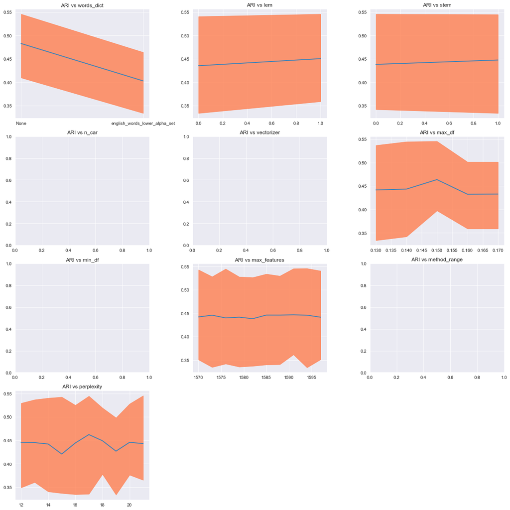

```
Matrice de confusion normalisée sur les 'true_labels' (en ligne):
```

|  | Baby Care | Beauty and Personal Care | Computers | Home Decor & Festive Needs | Home Furnishing | Kitchen & Dining | Watches |
| --- | --- | --- | --- | --- | --- | --- | --- |
| Baby Care | 0.65 | 0.13 | 0.00 | 0.03 | 0.19 | 0.01 | 0.00 |
| Beauty and Personal Care | 0.09 | 0.87 | 0.01 | 0.01 | 0.02 | 0.00 | 0.00 |
| Computers | 0.00 | 0.40 | 0.59 | 0.00 | 0.01 | 0.00 | 0.00 |
| Home Decor & Festive Needs | 0.02 | 0.07 | 0.08 | 0.77 | 0.04 | 0.01 | 0.00 |
| Home Furnishing | 0.15 | 0.04 | 0.00 | 0.00 | 0.81 | 0.00 | 0.00 |
| Kitchen & Dining | 0.01 | 0.23 | 0.05 | 0.01 | 0.02 | 0.67 | 0.00 |
| Watches | 0.00 | 0.00 | 0.00 | 0.00 | 0.00 | 0.00 | 1.00 |

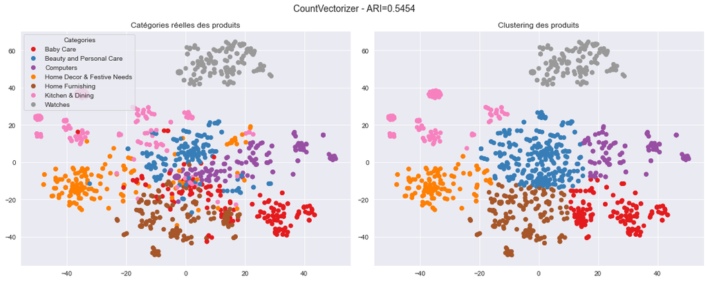

```python
# Paramètres
vectorizer = 'CountVectorizer'

paramGrid = {'words_dict': [None, 'english_words_lower_alpha_set'],
             'lem': [False, True],
             'stem': [False, True],
             'n_car': [0, 1, 2],
             'vectorizer': [vectorizer],
             'max_df': np.linspace(0.13, 0.17, 5),
             'min_df': [1],
             'max_features': np.append(np.arange(1570, 1600, 3), None),
             'method_range': ['tsne', 'pca']}

# Recherche
perplexity_range = np.arange(12, 22, 1)
#best_result = gridSearch(true_labels, paramGrid, func_vectorizer,
#                         perplexity_range=perplexity_range,
#                         language='english',
#                         save=vectorizer,
#                         verbose=False)

# Graphe de la recherche
filename = data_path + f"{vectorizer}.csv"
save = fig_path + f"{vectorizer} - search_graph.png"
best_result = search_graph(filename=filename, save=save, sep=';')

# Calcul des labels prédits du meilleur résultat
perplexity = best_result[-2]
pred_labels, perplexity, X = func_vectorizer(best_result,
                                             perplexity_range=[perplexity],
                                             language='english',
                                             get_X=True,
                                             verbose=False)

# Matrice de confusion
pred_labels = label_ordering(true_labels, pred_labels)

# Graphique de clustering
title = f"{vectorizer} - ARI={best_result[-1]}"
filename = fig_path + f"{vectorizer} - Clustering.png"
visu(X, true_labels, pred_labels, perplexity=perplexity,
     legend=legend, title=title, save=filename)
```

*retour sommaire*

### 5.3 - TF-IDF

Dans cette approche, nous recherchons à optimiser 8 paramètres (dont 4 de preprocessing et 3 propres à cette approche) pour obtenir un clustering avec l'indice d'ARI le plus élevé.

```
Lecture des données depuis le fichier ./P6_data/Flipkart/TfidfVectorizer.csv
Paramètres du meilleur résultat (0.7185)
```

```
words_dict                 None
lem                       False
stem                      False
n_car                         2
vectorizer      TfidfVectorizer
max_df                     0.15
min_df                        1
max_features               None
method_range               tsne
perplexity                   21
Name: 0, dtype: object
```

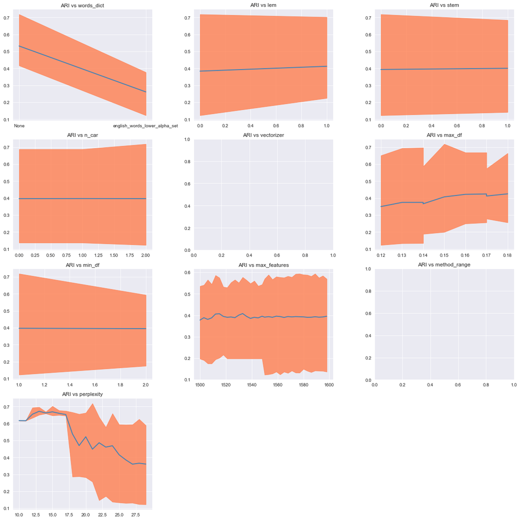

```
Meilleur résultat (0.7185):

Matrice de confusion normalisée sur les 'true_labels' (en ligne):
```

|  | Baby Care | Beauty and Personal Care | Computers | Home Decor & Festive Needs | Home Furnishing | Kitchen & Dining | Watches |
| --- | --- | --- | --- | --- | --- | --- | --- |
| Baby Care | 0.73 | 0.02 | 0.00 | 0.11 | 0.11 | 0.03 | 0.00 |
| Beauty and Personal Care | 0.00 | 0.89 | 0.01 | 0.08 | 0.00 | 0.02 | 0.00 |
| Computers | 0.00 | 0.00 | 0.89 | 0.01 | 0.01 | 0.09 | 0.00 |
| Home Decor & Festive Needs | 0.00 | 0.01 | 0.09 | 0.82 | 0.03 | 0.03 | 0.01 |
| Home Furnishing | 0.14 | 0.00 | 0.00 | 0.01 | 0.85 | 0.00 | 0.00 |
| Kitchen & Dining | 0.01 | 0.01 | 0.06 | 0.16 | 0.03 | 0.73 | 0.00 |
| Watches | 0.00 | 0.00 | 0.00 | 0.01 | 0.00 | 0.00 | 0.99 |

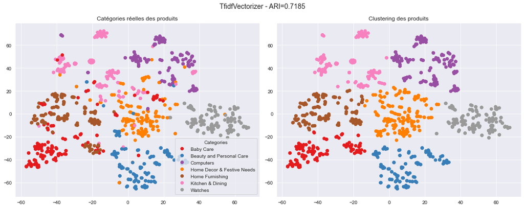

```python
# Paramètres
vectorizer='TfidfVectorizer'

paramGrid = {'words_dict': [None, 'english_words_lower_alpha_set'],
             'lem': [False],
             'stem': [False],
             'n_car': [0],
             'vectorizer': [vectorizer],
             'max_df': np.linspace(0.13, 0.17, 5),
             'min_df': [2],
             'max_features': [None],
             'method_range': ['tsne']}

# Recherche
perplexity_range = np.arange(10, 30, 1)
#best_result = gridSearch(true_labels, paramGrid, func_vectorizer,
#                         perplexity_range=perplexity_range,
#                         language='english',
#                         save=vectorizer,
#                         verbose=False)

# Graphe de la recherche
filename = data_path + f"{vectorizer}.csv"
save = fig_path + f"{vectorizer} - search_graph.png"
best_result = search_graph(filename=filename, save=save, sep=';')


# Calcul des labels prédits du meilleur résultat
print(f"\nMeilleur résultat ({best_result[-1]}):")
perplexity = best_result[-2]
pred_labels, perplexity, X = func_vectorizer(best_result,
                                             perplexity_range=[perplexity],
                                             language='english',
                                             get_X=True,
                                             verbose=False)

# Matrice de confusion
pred_labels = label_ordering(true_labels, pred_labels)

# Graphique de clustering
title = f"{vectorizer} - ARI={best_result[-1]}"
filename = fig_path + f"{vectorizer} - Clustering.png"
visu(X, true_labels, pred_labels, perplexity=perplexity,
     legend=legend, title=title, save=filename)
```

*retour sommaire*

Les approches de ce chapitre n'étaient pas demandé par ce projet mais apparaissent intéressantes au vu de la problématique et de leurs résultats.

```python
from sklearn.feature_extraction.text import CountVectorizer
from sklearn.decomposition import LatentDirichletAllocation
def func_lda(values, perplexity_range=[30], language='english',
             n_components=n_clusters, n_top_words=10, verbose=False):

    # Attribution des valeurs aux paramètres
    words_dict = values[0]
    lem = values[1]
    stem = values[2]
    n_car = values[3]
    max_df = values[4] if values[4]<=1 else int(values[4])
    min_df = values[5] if values[5]<1 else int(values[5])
    max_features = None if values[6] is None else int(values[6])

    # Preprocessing du corpus
    corpus = data_fk['description'].apply(lambda x: sow(
        x, filter_below_ncar=n_car, lem=lem, stem=stem,
        language=language, words_dict=words_dict)).values.tolist()

    # Vectorisation: CountVectorizer seulement
    vec = CountVectorizer(max_df=max_df, min_df=min_df, max_features=max_features, stop_words=language)
    X = vec.fit_transform(corpus)

    # Modèle LDA et prédiction des labels
    lda = LatentDirichletAllocation(
        n_components=n_components,
        learning_method='online',
        learning_offset=10.0,
        random_state=0)
    lda.fit(X)
    pred_labels = lda.transform(X).argmax(axis=1)

    # Dictionnaire avec les tops words de chaque catégorie
    if verbose:
        features = vec.get_feature_names_out()
        dict_categories = {}
        print(f"\n{n_top_words} tops words des {n_clusters} catégories prédites : ")
        for index, topic in enumerate(lda.components_):
            top_words = " ".join([features[i] for i in topic.argsort()[:-n_top_words - 1:-1]])
            print(f"→ {index+1}:", top_words)
            dict_categories.update({index: top_words})

    # Retourne les labels prédits pour valeur max de LDA
    return pred_labels, None
```

```
Lecture des données depuis le fichier ./P6_data/Flipkart/LDA.csv
Paramètres du meilleur résultat (0.586)
```

```
words_dict         None
lem               False
stem               True
n_car                 0
max_df             0.29
min_df                1
max_features   1,619.00
perplexity         None
Name: 0, dtype: object
```

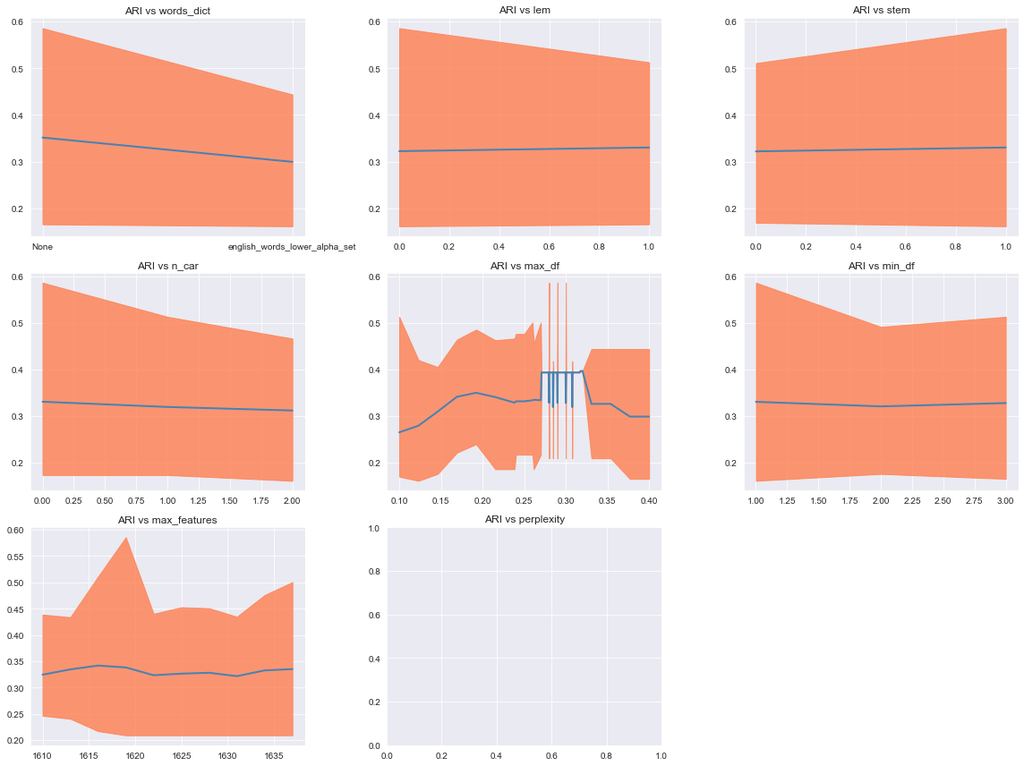

```
Meilleur résultat (0.586):

10 tops words des 7 catégories prédites :
→ 1: mug sticker ceram wall coffe perfect gift design love appli
→ 2: laptop warranti print shape pad mous inch qualiti multicolor adapt
→ 3: skin set combo hair type trait pack oil best pizza
→ 4: watch analog india men great discount women dial strap water
→ 5: cm showpiec light best use decor featur home box color
→ 6: cm design pack comfort color cover polyest model packag sale
→ 7: babi cotton girl fabric general boy ideal usb towel color

Matrice de confusion normalisée sur les 'true_labels' (en ligne):
```

|  | Baby Care | Beauty and Personal Care | Computers | Home Decor & Festive Needs | Home Furnishing | Kitchen & Dining | Watches |
| --- | --- | --- | --- | --- | --- | --- | --- |
| Baby Care | 0.72 | 0.05 | 0.01 | 0.05 | 0.09 | 0.08 | 0.00 |
| Beauty and Personal Care | 0.02 | 0.87 | 0.02 | 0.07 | 0.02 | 0.00 | 0.01 |
| Computers | 0.13 | 0.00 | 0.72 | 0.06 | 0.03 | 0.05 | 0.01 |
| Home Decor & Festive Needs | 0.01 | 0.01 | 0.00 | 0.89 | 0.02 | 0.06 | 0.02 |
| Home Furnishing | 0.14 | 0.00 | 0.00 | 0.02 | 0.84 | 0.00 | 0.00 |
| Kitchen & Dining | 0.08 | 0.17 | 0.03 | 0.11 | 0.11 | 0.49 | 0.01 |
| Watches | 0.00 | 0.00 | 0.01 | 0.01 | 0.01 | 0.01 | 0.97 |

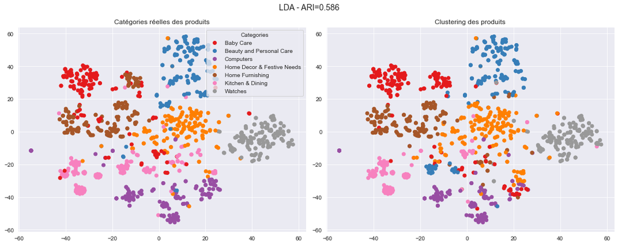

```
ARI = 0.586
```

```python
# Paramètres
paramGrid = {'words_dict': [None, 'english_words_lower_alpha_set'],
             'lem': [False, True],
             'stem': [False, True],
             'n_car': [0, 1, 2],
             'max_df': np.linspace(0.27, 0.32, 11),
             'min_df': [1],
             'max_features': np.append(np.arange(1615, 1640, 2), None)}

# Recherche
#best_result = gridSearch(true_labels, paramGrid, func_lda, language='english', save='LDA', verbose=False)

# Graphe de la recherche
filename = data_path + "LDA.csv"
save = fig_path + "LDA - search_graph.png"
best_result = search_graph(filename=filename, save=save, sep=';')

# Calcul des labels prédits du meilleur résultat
print(f"\nMeilleur résultat ({best_result[-1]}):")
pred_labels, p = func_lda(best_result, n_top_words=10, verbose=True)

# Matrice de confusion
pred_labels = label_ordering(true_labels, pred_labels)

# Visualisation du clustering
title = f"LDA - ARI={best_result[-1]}"
filename = fig_path + "LDA - Clustering.png"
visu(X, true_labels, pred_labels, perplexity=21, legend=legend, title=title, save=filename)

# Vérification de l'évaluation du clustering
ari = eval_ARI(true_labels, pred_labels)
print(f"\nARI = {ari}")
```

*retour sommaire*

```python
from sklearn.feature_extraction.text import TfidfVectorizer, CountVectorizer
from sklearn.decomposition import NMF
def func_nmf(values, perplexity_range=[30], language='english',
             n_components=n_clusters, n_top_words=10, verbose=False):

    # Attribution des valeurs aux paramètres
    words_dict = values[0]
    lem = values[1]
    stem = values[2]
    n_car = values[3]
    vectorizer = values[4]
    max_df = values[5] if values[5]<=1 else int(values[5])
    min_df = values[6] if values[6]<1 else int(values[6])
    max_features = None if values[7] is None else int(values[7])

    # Preprocessing du corpus
    corpus = data_fk['description'].apply(lambda x: sow(
        x, filter_below_ncar=n_car, lem=lem, stem=stem,
        language=language, words_dict=words_dict)).values.tolist()

    # Vectorisation: CountVectorizer ou TfidfVectorizer
    if vectorizer=='CountVectorizer':
        vec = CountVectorizer(max_df=max_df, min_df=min_df,
                              max_features=max_features, stop_words=language)
    elif vectorizer=='TfidfVectorizer':
        vec = TfidfVectorizer(max_df=max_df, min_df=min_df,
                              max_features=max_features, stop_words=language)
    else:
        print("\n*** Wrong vectorizer ***")
        return
    X = vec.fit_transform(corpus)

    # Modèle NMF et prédiction des labels
    nmf = NMF(n_components=n_components, init='nndsvd', max_iter=500, random_state=0)
    nmf.fit(X)
    pred_labels = nmf.transform(X).argmax(axis=1)

    # Dictionnaire avec les tops words de chaque catégorie
    if verbose:
        features = vec.get_feature_names_out()
        dict_categories = {}
        print(f"\n{n_top_words} tops words des {n_clusters} catégories prédites : ")
        for index, topic in enumerate(nmf.components_):
            top_words = " ".join([features[i] for i in topic.argsort()[:-n_top_words - 1:-1]])
            print(f"→ {index+1}:", top_words)
            dict_categories.update({index: top_words})

    # Retourne les labels prédits pour valeur max de LDA
    return pred_labels, None
```

```
Lecture des données depuis le fichier ./P6_data/Flipkart/NMF.csv
Paramètres du meilleur résultat (0.5692)
```

```
words_dict                 None
lem                        True
stem                       True
n_car                         0
vectorizer      TfidfVectorizer
max_df                     0.15
min_df                        2
max_features           1,478.00
perplexity                 None
Name: 0, dtype: object
```

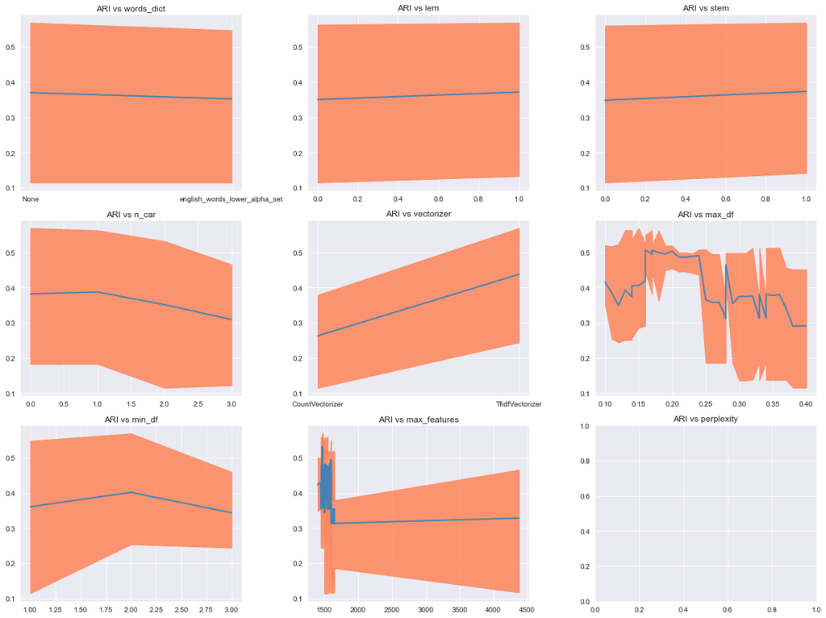

```
Meilleur résultat (0.5692):

10 tops words des 7 catégories prédites :
→ 1: watch analog men discount woman sonata dial strap maximum resist
→ 2: mug ceram coffe perfect rockmantra gift love prithish safe microwav
→ 3: babi girl fabric dress cotton boy sleev neck print ideal
→ 4: laptop batteri cell hp pavilion lapguard warranti skin usb adapt
→ 5: showpiec handicraft brass statu buddha ganesha exot gift decor lal
→ 6: towel cotton bath abstract singl quilt comfort doubl blanket multicolor
→ 7: combo denver playboy vj engag yardley adida skin ice deodor

Matrice de confusion normalisée sur les 'true_labels' (en ligne):
```

|  | Baby Care | Beauty and Personal Care | Computers | Home Decor & Festive Needs | Home Furnishing | Kitchen & Dining | Watches |
| --- | --- | --- | --- | --- | --- | --- | --- |
| Baby Care | 0.70 | 0.02 | 0.08 | 0.02 | 0.15 | 0.01 | 0.01 |
| Beauty and Personal Care | 0.10 | 0.67 | 0.07 | 0.05 | 0.06 | 0.03 | 0.03 |
| Computers | 0.00 | 0.00 | 0.89 | 0.05 | 0.01 | 0.01 | 0.05 |
| Home Decor & Festive Needs | 0.01 | 0.01 | 0.15 | 0.71 | 0.07 | 0.04 | 0.03 |
| Home Furnishing | 0.09 | 0.00 | 0.02 | 0.00 | 0.89 | 0.00 | 0.00 |
| Kitchen & Dining | 0.02 | 0.01 | 0.19 | 0.01 | 0.07 | 0.66 | 0.04 |
| Watches | 0.00 | 0.00 | 0.01 | 0.00 | 0.00 | 0.00 | 0.99 |

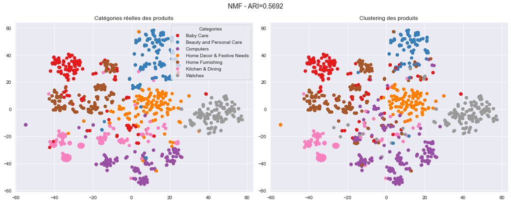

```
ARI = 0.5692
```

```python
# Paramètres - TfidfVectorizer
paramGrid = [{'words_dict': [None, 'english_words_lower_alpha_set'],
              'lem': [False, True],
              'stem': [False, True],
              'n_car': [0, 1, 2],
              'vectorizer' : ['CountVectorizer'],
              'max_df': np.linspace(0.25, 0.35, 11),
              'min_df': [1],
              'max_features': np.append(np.arange(1580, 1650, 3), None)},
             {'words_dict': [None, 'english_words_lower_alpha_set'],
              'lem': [False, True],
              'stem': [False, True],
              'n_car': [0, 1, 2],
              'vectorizer' : ['TfidfVectorizer'],
              'max_df': np.linspace(0.13, 0.17, 5),
              'min_df': [1],
              'max_features': np.append(np.arange(1460, 1482, 3), None)}]

# Recherche
#best_result = gridSearch(true_labels, paramGrid, func_nmf, language='english', save='NMF', verbose=False)

# Graphe de la recherche
filename = data_path + "NMF.csv"
save = fig_path + "NMF - search_graph.png"
best_result = search_graph(filename=filename, save=save, sep=';')

# Calcul des labels prédits du meilleur résultat
print(f"\nMeilleur résultat ({best_result[-1]}):")
pred_labels, p = func_nmf(best_result, n_top_words=10, verbose=True)

# Matrice de confusion
pred_labels = label_ordering(true_labels, pred_labels)

# Visualisation du clustering
title = f"NMF - ARI={best_result[-1]}"
filename = fig_path + "NMF - Clustering.png"
visu(X, true_labels, pred_labels, perplexity=21, legend=legend, title=title, save=filename)

# Vérification de l'évaluation du clustering
ari = eval_ARI(true_labels, pred_labels)
print(f"\nARI = {ari}")
```

*retour sommaire*

Les fonctions utilisées par cette approche:

- le preprocessing du texte: codage avec le dictionnaire des mots uniques et padding,
- constitution de la matrice d'embedding à partir des vecteurs fournis par gensim,
- fonction d'embedding du texte avec un modèle spécifié avec Keras,
- fonction spécifique à cette approche utiliée pour la recherche sur grille.

```python
# Fonction de preprocessing de l'ensemble des documents
# Attribue un nombre à chaque mot unique du corpus (dictionnaire)
# Code chaque document du corpus (ligne) selon les mots uniques (features)
# avec le numéro du mot unique de la feature (dictionnaire)
# et complète avec des zéros jusqu'à maxlen
import tensorflow as tf
from keras.preprocessing.text import Tokenizer as Tk
def doc_preprocessing(corpus, maxlen):
    # Vectorisation des documents du corpus
    tokenizer = Tk()
    tokenizer.fit_on_texts(corpus)
    x_sentences = tf.keras.utils.pad_sequences(tokenizer.texts_to_sequences(corpus), maxlen=maxlen, padding='post')
    return x_sentences, tokenizer
```

```python
# Fonction de constitution de la matrice d'embedding à partir des vecteurs du modèle w2v
def embed_matrix(w2v, tokenizer, w2v_size=100, verbose=False):
    w2v_words = w2v.index_to_key
    if verbose:
        print(f"Volume de vocabulaire : {len(w2v_words)} mots")
    word_index = tokenizer.word_index
    vocab_size = len(word_index) + 1
    embedding_matrix = np.zeros((vocab_size, w2v_size))
    i = 0
    j = 0
    for word, idx in word_index.items():  # liste des tuples (mot unique, numéro associé) du corpus
        i += 1
        if word in w2v_words:
            j += 1
            embedding_vector = w2v[word]  # Vecteur du mot 'word' embedded sur w2v_size features
            if embedding_vector is not None:
                embedding_matrix[idx] = w2v[word]
    if verbose:
        print("Word embedding rate : ", np.round(j / i, 4))
        print("Embedding matrix: %s" % str(embedding_matrix.shape))
    return vocab_size, embedding_matrix
```

```python
# Fonction de création des vecteurs d'embedding
# retourne le corpus (document=sentence) vectorisé (1 vecteur moyen par sentence)
from gensim.models import Word2Vec
from keras import layers
from keras import models
def w2v_embed(corpus, w2v_size=100, w2v_window=5, w2v_min_count=1, maxlen=1000, save=None, verbose=False):

    # Création du modèle Word2Vec: code chaque mot unique du corpus sur un vecteur de taille vector_size
    model = Word2Vec(sentences=corpus, vector_size=w2v_size,
                     window=w2v_window, min_count=w2v_min_count,
                     workers=4)
    w2v = model.wv

    if save is not None:
        model.save(save + ".model")
        w2v.save(save + ".wordvectors")
    del model  # Supprime le modèle dont on a plus besoin

    # Préprocessing des documents du corpus (x_sentences)
    x_sentences, tokenizer = doc_preprocessing(corpus, maxlen)

    # Création matrice d'embeddings
    vocab_size, embedding_matrix = embed_matrix(w2v, tokenizer, w2v_size=w2v_size)

    # Création du modèle d'embedding
    word_input = layers.Input(shape=(maxlen,), dtype='float64')
    word_embedding = layers.Embedding(input_dim=vocab_size,
                                      output_dim=w2v_size,
                                      weights=[embedding_matrix],
                                      input_length=maxlen)(word_input)
    word_vec = layers.GlobalAveragePooling1D()(word_embedding) # vecteur moyen par sentence (doc)
    embed_model = models.Model([word_input], word_vec)
    if verbose: print("\nModel summary :", embed_model.summary())

    # Exécution du modèle
    embeddings = embed_model.predict(x_sentences)
    if verbose: print("Embedding shape :", embeddings.shape)

    return pd.DataFrame(embeddings)
```

```python
# Fonction utilisée par la recherche sur grille
def func_w2v(values, perplexity_range=[30], language='english',
             verbose=False, get_X=False):

    # Affectation des variables
    words_dict = values[0]
    lem = values[1]
    stem = values[2]
    n_car = values[3]
    w2v_size = values[4]
    w2v_window = values[5]
    w2v_min_count = values[6]
    method = values[7]

    # Preprocessing du corpus
    corpus = data_fk['description'].apply(lambda x: str2low(
        x, filter_below_ncar=n_car, lem=lem, stem=stem,
        language=language, words_dict=words_dict)).values.tolist()
    maxlen = np.asarray([len(x) for x in corpus], dtype=int).max()

    # Codage du corpus avec la matrice d'embedding
    X = w2v_embed(corpus, w2v_size=w2v_size, w2v_window=w2v_window,
                      w2v_min_count=w2v_min_count, maxlen=maxlen)

    # Réduction de la dimensionnalité et clustering
    return label_predict(X, method=method, perplexity=perplexity_range, expl_var=expl_var,
                   n_clusters=n_clusters, get_X=get_X, verbose=verbose)
```

*retour sommaire*

```
Lecture des données depuis le fichier ./P6_data/Flipkart/Word2Vec.csv
Paramètres du meilleur résultat (0.3798)
```

```
words_dict       None
lem              True
stem             True
n_car               0
w2v_size          150
w2v_window         79
w2v_min_count       8
method           tsne
perplexity         34
Name: 0, dtype: object
```

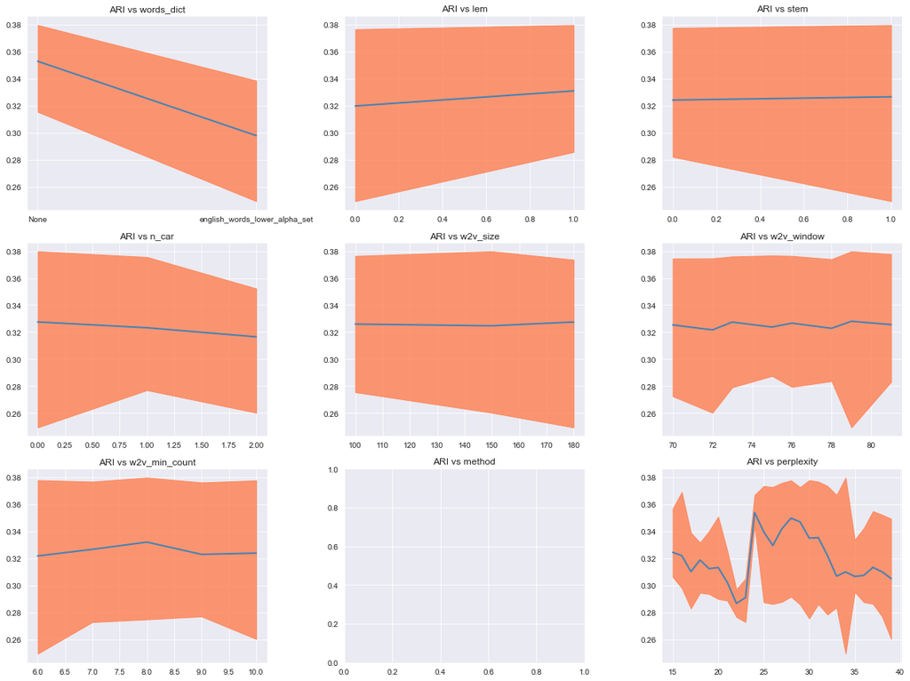

```
Meilleur résultat (0.3798):

Matrice de confusion normalisée sur les 'true_labels' (en ligne):
```

|  | Baby Care | Beauty and Personal Care | Computers | Home Decor & Festive Needs | Home Furnishing | Kitchen & Dining | Watches |
| --- | --- | --- | --- | --- | --- | --- | --- |
| Baby Care | 0.57 | 0.00 | 0.05 | 0.10 | 0.18 | 0.09 | 0.00 |
| Beauty and Personal Care | 0.00 | 0.62 | 0.17 | 0.05 | 0.04 | 0.11 | 0.00 |
| Computers | 0.00 | 0.00 | 0.61 | 0.37 | 0.01 | 0.01 | 0.00 |
| Home Decor & Festive Needs | 0.01 | 0.00 | 0.02 | 0.51 | 0.08 | 0.39 | 0.00 |
| Home Furnishing | 0.08 | 0.00 | 0.01 | 0.00 | 0.54 | 0.37 | 0.00 |
| Kitchen & Dining | 0.00 | 0.01 | 0.03 | 0.33 | 0.04 | 0.59 | 0.00 |
| Watches | 0.00 | 0.00 | 0.07 | 0.00 | 0.00 | 0.01 | 0.91 |

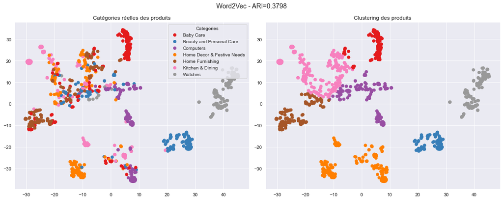

```
ARI = 0.3752
```

```python
# Paramètres
paramGrid = {'words_dict': [None, 'english_words_lower_alpha_set'],
             'lem': [False, True],
             'stem': [False, True],
             'n_car': [0, 1, 2],
             'w2v_size': [150],
             'w2v_window': np.arange(72, 82, 3),
             'w2v_min_count': np.arange(9, 11, 1),
             'method': ['tsne']}

# Recherche
perplexity_range = np.arange(25, 40, 1)
#best_result = gridSearch(true_labels, paramGrid, func_w2v,
#                         perplexity_range=perplexity_range,
#                         language='english',
#                         save='Word2Vec',
#                         verbose=False)

# Graphe de la recherche
filename = data_path + "Word2Vec.csv"
save = fig_path + "Word2Vec - search_graph.png"
best_result = search_graph(filename=filename, save=save, sep=';')

# Calcul des labels prédits du meilleur résultat
print(f"\nMeilleur résultat ({best_result[-1]}):")
perplexity = best_result[-2]
pred_labels, perplexity, X = func_w2v(best_result,
                                      perplexity_range=[perplexity],
                                      language='english',
                                      get_X=True,
                                      verbose=False)

# Matrice de confusion
pred_labels = label_ordering(true_labels, pred_labels)

# Graphique de clustering
title = f"Word2Vec - ARI={best_result[-1]}"
filename = fig_path + "Word2Vec - Clustering.png"
visu(X, true_labels, pred_labels, perplexity=perplexity,
     legend=legend, title=title, save=filename)

# Vérification de l'évaluation du clustering
ari = eval_ARI(true_labels, pred_labels)
print(f"\nARI = {ari}")
```

*retour sommaire*

## 8 - Approche de type word/sentence embedding avec BERT (Bidirectional Encoder Representations from Transformers)

### 8.1 - Fonctions de BERT

```python
# Tensorflow
import tensorflow as tf
import tensorflow_hub as hub
import tensorflow_text as text

# Environnement et version
import os
os.environ["TF_KERAS"]='1'
print(tf.__version__)
print("Num GPUs Available: ", len(tf.config.experimental.list_physical_devices('GPU')))
print(tf.test.is_built_with_cuda())
```

```
2.9.1
Num GPUs Available:  0
True
```

```python
# Fonction d'encodage des sentences avec 'encode_plus' (pour tokenisation par batch)
def bert_inp_fct(sentences, bert_tokenizer, max_length=None):
    input_ids = []
    token_type_ids = []
    attention_mask = []

    for sent in sentences:
        bert_inp = bert_tokenizer.encode_plus(sent,
                                              add_special_tokens=True,
                                              max_length=max_length, # si None alors valeur max du modèle
                                              padding='max_length', # padding jusqu'à max_length ou max du modèle
                                              return_attention_mask=True,
                                              return_token_type_ids=True,
                                              truncation=True,
                                              return_tensors="tf")

        input_ids.append(bert_inp['input_ids'][0])
        token_type_ids.append(bert_inp['token_type_ids'][0])
        attention_mask.append(bert_inp['attention_mask'][0])

    input_ids = np.asarray(input_ids)
    token_type_ids = np.asarray(token_type_ids)
    attention_mask = np.array(attention_mask)

    return input_ids, token_type_ids, attention_mask
```

```python
import os.path as path
def HF_features_extraction(checkpoint, ff, text, verbose=False):
    if path.exists(ff):
        # Récupération du preprocessing depuis le fichier ff
        if verbose: print(f"Récupération des features depuis le fichier {ff}")
        ff_file = np.load(ff)
        features = ff_file['features_bert']
        ff_file.close()
    else:
        # Modèle Fill-mask
        if checkpoint=='bert-base-uncased':
            from transformers import BertTokenizer, TFBertModel
            tokenizer = BertTokenizer.from_pretrained(checkpoint)
            model = TFBertModel.from_pretrained(checkpoint)
        # Modèle Fill-mask et text classification
        elif checkpoint in ['distilbert-base-uncased', 'distilbert-base-uncased-finetuned-sst-2-english']:
            from transformers import DistilBertTokenizer, TFDistilBertModel
            tokenizer = DistilBertTokenizer.from_pretrained(checkpoint)
            model = TFDistilBertModel.from_pretrained(checkpoint)
        # Modèle Fill-mask
        elif checkpoint=='roberta-base':
            from transformers import RobertaTokenizer, TFRobertaModel
            tokenizer = RobertaTokenizer.from_pretrained(checkpoint)
            model = TFRobertaModel.from_pretrained(checkpoint)
        else:
            print("Model checkpoint does not exists")
            return None

        # Récupération et sauvegarde des features
        encoded_input = tokenizer(text, padding=True, truncation=True, return_tensors='tf')
        output = model(encoded_input)
        lhs = np.asarray(output.last_hidden_state)
        features = lhs.mean(axis=1)
        np.savez(ff, features_bert=features)
        if verbose: print(f"Sauvegarde des features dans le fichier {ff}")

    return features
```

```python
# Fonction d'extraction des features par batch
# Problème avec AutoTokenizer.from_pretrained pour HF: ne fonctionne qu'avec 'bert-base-uncased'
# L'extraction des features avec les modèles de HF est effectuée par HF_features_extraction
import os.path as path
from transformers import AutoTokenizer
def feature_BERT_fct(model, preprocessor, sentences, ff, b_size=100, mode='HF', verbose=False):

    # Extraction des features
    if path.exists(ff):
        # Récupération des features depuis le fichier ff
        if verbose: print(f"Récupération des features depuis le fichier {ff}")
        ff_file = np.load(ff)
        features_bert = np.array(ff_file['features_bert'])
        ff_file.close()

    else:
        tokenizer = AutoTokenizer.from_pretrained(preprocessor)
        for step in range(len(sentences)//b_size):
            idx = step * b_size
            idx_end = len(sentences) if idx+2*b_size>len(sentences) else idx+b_size
            if verbose: print(f"Processing des textes {idx} à {idx_end-1}")
            input_ids, token_type_ids, attention_mask = bert_inp_fct(sentences[idx:idx_end], tokenizer)


            if mode == 'HF':  # Bert HuggingFace
                outputs = model.predict([input_ids, attention_mask, token_type_ids], batch_size=b_size)
                last_hidden_states = outputs.last_hidden_state

            if mode == 'TFhub':  # Bert Tensorflow Hub
                text_preprocessed = {"input_word_ids": input_ids,
                                     "input_mask": attention_mask,
                                     "input_type_ids": token_type_ids}
                outputs = model(text_preprocessed)
                last_hidden_states = outputs['sequence_output']

            if step == 0:
                last_hidden_states_tot = last_hidden_states
            else:
                last_hidden_states_tot = np.concatenate((last_hidden_states_tot, last_hidden_states))

        features_bert = np.array(last_hidden_states_tot).mean(axis=1)
        np.savez(ff, features_bert=features_bert)
        if verbose: print(f"Sauvegarde des features dans le fichier {ff}")

    return features_bert
```

```python
# Fonction utilisée par la recherche sur grille
from transformers import TFAutoModel
def func_bert(values, perplexity_range=[30], language='english',
             verbose=False, get_X=False):

    # Affectation des variables
    mode = values[0]
    checkpoint = values[1]
    dim_red = values[2]
    print(f"Modèle {mode} - {checkpoint}")

    if mode=='HF':
        # Création des features pour HF (X=features_bert) - pour utilisation avec feature_BERT_fct
        #model_HF = TFAutoModel.from_pretrained(checkpoint)
        #preprocessor = checkpoint

        # Nom du fichier de récupération/sauvegarde des features
        model_name = checkpoint.replace('/', '_')
        ff = data_path + "BERT_" + mode + "_" + model_name + ".npz"

        # Extraction des features avec feature_BERT_fct
        #X = feature_BERT_fct(model_HF, preprocessor, sentences, ff, mode=mode, verbose=verbose)

        # Extraction des features avec HF_features_extraction
        X = HF_features_extraction(checkpoint, ff, sentences, verbose=False)

    elif mode=='TFhub':
        # Création des features pour TFhub (X=features_bert)
        model_TFhub = hub.KerasLayer(checkpoint, trainable=True)
        preprocessor = 'bert-base-uncased'

        # Nom du fichier de récupération/sauvegarde des features
        model_name = "_".join(checkpoint.replace('/', ' ').split(' ')[3:])
        ff = data_path + "BERT_" + mode + "_" + model_name + ".npz"

        # Extraction des features
        X = feature_BERT_fct(model_TFhub, preprocessor, sentences, ff, mode=mode, verbose=verbose)

    else: X = None

    if verbose:
        print(f"\nDimensions des features BERT - {mode} :", X.shape)

    # Réduction de la dimensionnalité et clustering
    return label_predict(X, method=dim_red, perplexity=perplexity_range, expl_var=expl_var,
                   n_clusters=n_clusters, get_X=get_X, verbose=verbose)
```

*retour sommaire*

### 8.2 - BERT

```
Lecture des données depuis le fichier ./P6_data/Flipkart/BERT.csv
Paramètres du meilleur résultat (0.3213)
```

```
mode                               HF
checkpoint    distilbert-base-uncased
dim_red                          tsne
perplexity                      25.00
Name: 0, dtype: object
```

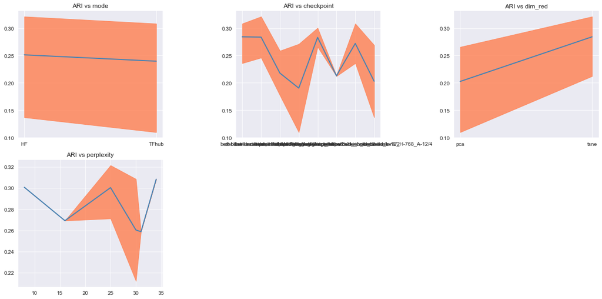

```
Meilleur résultat (0.3213):
Modèle HF - distilbert-base-uncased

Matrice de confusion normalisée sur les 'true_labels' (en ligne):
```

|  | Baby Care | Beauty and Personal Care | Computers | Home Decor & Festive Needs | Home Furnishing | Kitchen & Dining | Watches |
| --- | --- | --- | --- | --- | --- | --- | --- |
| Baby Care | 0.63 | 0.00 | 0.03 | 0.09 | 0.13 | 0.08 | 0.03 |
| Beauty and Personal Care | 0.15 | 0.53 | 0.07 | 0.14 | 0.00 | 0.11 | 0.00 |
| Computers | 0.00 | 0.45 | 0.17 | 0.17 | 0.00 | 0.19 | 0.01 |
| Home Decor & Festive Needs | 0.00 | 0.00 | 0.18 | 0.55 | 0.00 | 0.27 | 0.00 |
| Home Furnishing | 0.08 | 0.00 | 0.34 | 0.00 | 0.49 | 0.09 | 0.00 |
| Kitchen & Dining | 0.01 | 0.01 | 0.14 | 0.35 | 0.01 | 0.49 | 0.00 |
| Watches | 0.00 | 0.00 | 0.07 | 0.00 | 0.00 | 0.03 | 0.89 |

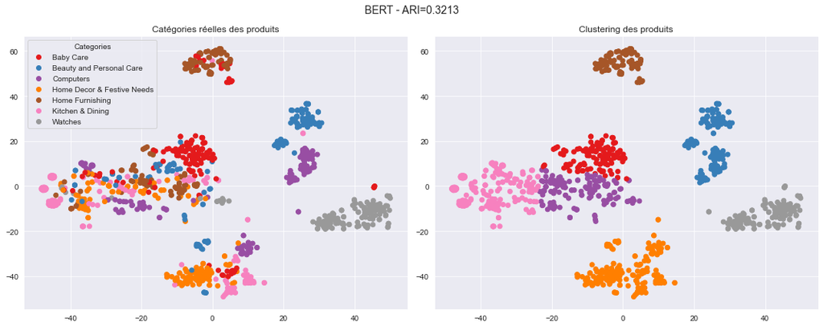

```
ARI = 0.3213
```

```python
# Paramètres
paramGrid = [
    {'mode': ['HF'],
     'checkpoint': ['bert-base-uncased',
                    'distilbert-base-uncased',
                    'distilbert-base-uncased-finetuned-sst-2-english',
                    'roberta-base'],
     'dim_red': ['tsne', 'pca']},
    {'mode': ['TFhub'],
     'checkpoint': ['https://tfhub.dev/tensorflow/bert_en_uncased_L-12_H-768_A-12/4',
                    'https://tfhub.dev/google/experts/bert/wiki_books/2',
                    'https://tfhub.dev/google/experts/bert/wiki_books/mnli/2',
                    'https://tfhub.dev/google/electra_base/2'],
     'dim_red': ['tsne', 'pca']}]

# Recherche
sentences = data_fk['description'].values.tolist()
perplexity_range = np.arange(5, 40, 1)

#best_result = gridSearch(true_labels, paramGrid, func_bert,
#                         perplexity_range=perplexity_range,
#                         language='english',
#                         save='BERT',
#                         verbose=False)

# Graphe de la recherche
filename = data_path + "BERT.csv"
save = fig_path + "BERT - search_graph.png"
best_result = search_graph(filename=filename, save=save, sep=';')

# Calcul des labels prédits du meilleur résultat
print(f"\nMeilleur résultat ({best_result[-1]}):")
perplexity = best_result[-2]
pred_labels, perplexity, X = func_bert(best_result,
                                      perplexity_range=[perplexity],
                                      language='english',
                                      get_X=True,
                                      verbose=False)

# Matrice de confusion
pred_labels = label_ordering(true_labels, pred_labels)

# Graphique de clustering input_word_ids
title = f"BERT - ARI={best_result[-1]}"
filename = fig_path + "BERT - Clustering.png"
visu(X, true_labels, pred_labels, perplexity=perplexity,
     legend=legend, title=title, save=filename)

# Vérification de l'évaluation du clustering
ari = eval_ARI(true_labels, pred_labels)
print(f"\nARI = {ari}")
```

*retour sommaire*

## 9 - Approche de type word/sentence embedding avec USE (Universal Sentence Encoder)

### 9.1 - Fonctions de USE

```python
import os
os.environ["TF_KERAS"]='1'
print(tf.__version__)
print("Num GPUs Available: ", len(tf.config.experimental.list_physical_devices('GPU')))
print(tf.test.is_built_with_cuda())

import tensorflow_hub as hub
embed = hub.load("https://tfhub.dev/google/universal-sentence-encoder/4")
```

```
2.9.1
Num GPUs Available:  0
True
```

```python
# Fonction de création ou récupération des features
import os.path as path

def feature_USE_fct(sentences, b_size=1050, feat_filename=None, verbose=False) :

    # Récupération des features depuis le fichier s'il existe
    if (feat_filename is not None) and (path.exists(feat_filename)):
        if verbose: print(f"Récupération des features depuis le fichier {feat_filename}")
        file = np.load(feat_filename)
        features = file['features_use']
        file.close()

    # Extraction des features sinon
    else:
        if verbose: print("Extraction des features")
        for step in range(len(sentences)//b_size) :
            idx = step*b_size
            idx_end = len(sentences) if idx+2*b_size>len(sentences) else idx+b_size
            if verbose: print(f"Processing des textes {idx} à {idx_end-1}")
            feat = np.asarray(embed(sentences[idx:idx_end]))
            if step ==0 :
                features = feat
            else :
                features = np.concatenate((features,feat))
        if verbose: print(f"Dimensions des features: {features.shape}")
        np.savez(feat_filename, features_use=features)
        if verbose: print(f"Sauvegarde des features dans le fichier {feat_filename}")

    return features
```

```python
# Fonction utilisée par la recherche sur grille
def func_use(values, perplexity_range=[30], language='english', verbose=False, get_X=False):

    # Affectation des variables
    words_dict = values[0]
    lem = values[1]
    stem = values[2]
    n_car = values[3]
    dim_red = values[4]

    # Preprocessing du corpus et nom du fichier de sauvegarde des features
    if (words_dict is None) and (lem is None) and (stem is None) and (n_car is None):
        sentences = data_fk['description'].values.tolist()
        feat_filename = data_path + "USE_features.npz"
    else:
        sentences = data_fk['description'].apply(lambda x: sow(
            x, filter_below_ncar=n_car, lem=lem, stem=stem,
            language=language, words_dict=words_dict)).values.tolist()
        pp_var_name = "" if words_dict is None else str(words_dict)[:3]
        pp_var_name += str(lem)[0] + str(stem)[0] + str(n_car) + str(dim_red)
        feat_filename = data_path + pp_var_name + "_USE_features.npz"

    # Création des features (X=features_use)
    X = feature_USE_fct(sentences, feat_filename=feat_filename, verbose=verbose)
    if verbose: print(f"\nDimensions des features de USE :", X.shape)

    # Réduction de la dimensionnalité et clustering
    return label_predict(X, method=dim_red, perplexity=perplexity_range, expl_var=expl_var,
                   n_clusters=n_clusters, get_X=get_X, verbose=verbose)
```

*retour sommaire*

### 9.2 - USE

```
Lecture des données depuis le fichier ./P6_data/Flipkart/USE.csv
Paramètres du meilleur résultat (0.4796)
```

```
words_dict    english_words_lower_alpha_set
lem                                   False
stem                                  False
n_car                                  0.00
dim_red                                tsne
perplexity                            14.00
Name: 0, dtype: object
```

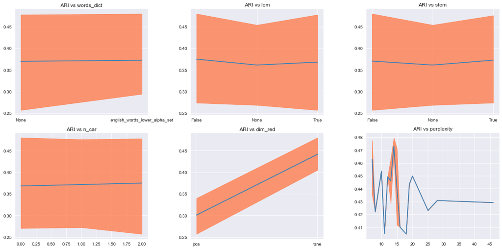

```
Meilleur résultat (0.4796):
Récupération des features depuis le fichier ./P6_data/Flipkart/engFF0.0tsne_USE_features.npz

Dimensions des features de USE : (1050, 512)

Matrice de confusion normalisée sur les 'true_labels' (en ligne):
```

|  | Baby Care | Beauty and Personal Care | Computers | Home Decor & Festive Needs | Home Furnishing | Kitchen & Dining | Watches |
| --- | --- | --- | --- | --- | --- | --- | --- |
| Baby Care | 0.72 | 0.01 | 0.09 | 0.03 | 0.13 | 0.01 | 0.00 |
| Beauty and Personal Care | 0.05 | 0.53 | 0.35 | 0.03 | 0.00 | 0.03 | 0.00 |
| Computers | 0.00 | 0.50 | 0.43 | 0.06 | 0.00 | 0.01 | 0.00 |
| Home Decor & Festive Needs | 0.01 | 0.00 | 0.08 | 0.55 | 0.00 | 0.33 | 0.03 |
| Home Furnishing | 0.50 | 0.00 | 0.00 | 0.00 | 0.49 | 0.01 | 0.00 |
| Kitchen & Dining | 0.00 | 0.02 | 0.01 | 0.16 | 0.01 | 0.81 | 0.00 |
| Watches | 0.00 | 0.00 | 0.00 | 0.00 | 0.00 | 0.00 | 1.00 |

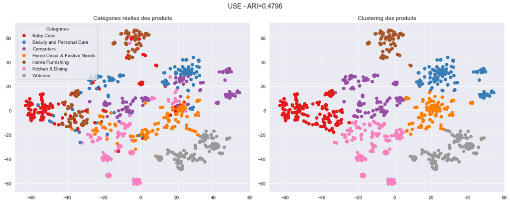

```
ARI = 0.4796
```

```python
# Paramètres
# USE ne requiert pas de preprocessing en entrée → premier jeu de paramètres
# L'exploration de preprocessing en ante est néanmoins exploré dans le 2ème jeu de paramètres
paramGrid = [{'words_dict': [None],
              'lem': [None],
              'stem': [None],
              'n_car': [None],
              'dim_red': ['tsne', 'pca']},
             {'words_dict': [None, 'english_words_lower_alpha_set'],
              'lem': [False, True],
              'stem': [False, True],
              'n_car': [0, 1, 2],
              'dim_red': ['tsne', 'pca']}]

# Recherche
perplexity_range = np.arange(5, 50, 1)
#best_result = gridSearch(true_labels, paramGrid, func_use,
#                         perplexity_range=perplexity_range,
#                         language='english',
#                         save='USE',
#                         verbose=True)

# Graphe de la recherche
filename = data_path + "USE.csv"
save = fig_path + "USE - search_graph.png"
best_result = search_graph(filename=filename, save=save, sep=';')

# Calcul des labels prédits du meilleur résultat
print(f"\nMeilleur résultat ({best_result[-1]}):")
perplexity = best_result[-2]

pred_labels, perplexity, X = func_use(best_result,
                                      perplexity_range=[perplexity],
                                      language='english',
                                      get_X=True,
                                      verbose=True)

# Matrice de confusion
pred_labels = label_ordering(true_labels, pred_labels)

# Graphique de clustering
title = f"USE - ARI={best_result[-1]}"
filename = fig_path + "USE - Clustering.png"
visu(X, true_labels, pred_labels, perplexity=perplexity,
     legend=legend, title=title, save=filename)

# Vérification de l'évaluation du clustering
ari = eval_ARI(true_labels, pred_labels)
print(f"\nARI = {ari}")
```

*retour sommaire*

## 10 - Conclusion sur le clustering textuel

La table ci-après résume les résultats obtenus par l'analyse NLP avec les 7 approches de ce notebook. Les approches les plus simples (BOW, LDA) donnent les meilleurs résultats, ce qui n'est pas surprenant car ce projet s'appuie essentiellement sur des mots-clés.

```python
conclusion = {'Approche': [], 'ARI': [], 'Clustering': [], 'Recherche': []}
approaches = ['CountVectorizer', 'TfidfVectorizer', 'Word2Vec', 'LDA', 'NMF', 'BERT', 'USE']

for approach in approaches:
    # Fichiers liés
    datafile = data_path + approach + ".csv"
    figclust = fig_path + f"{approach} - Clustering.png"
    figsearch = fig_path + f"{approach} - search_graph.png"

    # Récupération du meilleur résultat
    df_result = pd.read_csv(datafile, sep=';')
    df_result = df_result.drop_duplicates(ignore_index=True)
    best_result = df_result.sort_values(by='ARI', ascending=False, ignore_index=True).iloc[0]

    # Renseignement du dictionnaire
    conclusion['Approche'].append(approach)
    conclusion['ARI'].append(best_result[-1])
    conclusion['Clustering'].append(figclust)
    conclusion['Recherche'].append(figsearch)

# Conversion du dictionnaire en dataframe
df_result = pd.DataFrame.from_dict(conclusion)
df_result.sort_values(by='ARI', ascending=False, ignore_index=True, inplace=True)

# Affichage du dataframe des résultats avec fichiers graphiques clickables
import os
def make_link(filename):
    url = os.path.basename(filename)
    return f"<a target='_blank' href='{filename}'>{url}</a>"

display(df_result.style.format({'Clustering': make_link, 'Recherche': make_link}, precision=2))

# Sauvegarde du résultat dans un fichier csv
filename = data_path + "Text clustering results.csv"
df_result.to_csv(filename, sep=';', index=False)
```

|  | Approche | ARI | Clustering | Recherche |
| --- | --- | --- | --- | --- |
| 0 | TfidfVectorizer | 0.72 | TfidfVectorizer - Clustering.png | TfidfVectorizer - search_graph.png |
| 1 | LDA | 0.59 | LDA - Clustering.png | LDA - search_graph.png |
| 2 | NMF | 0.57 | NMF - Clustering.png | NMF - search_graph.png |
| 3 | CountVectorizer | 0.55 | CountVectorizer - Clustering.png | CountVectorizer - search_graph.png |
| 4 | USE | 0.48 | USE - Clustering.png | USE - search_graph.png |
| 5 | Word2Vec | 0.38 | Word2Vec - Clustering.png | Word2Vec - search_graph.png |
| 6 | BERT | 0.32 | BERT - Clustering.png | BERT - search_graph.png |

*retour sommaire*

## 11 - Approche CV avec SIFT

Nous abordons ici une approche computer vision (CV) avec la méthode SIFT afin d'effectuer le clustering des images.

Cette approche ne permettra cependant pas de proposer un résultat probant compte tenu d'un niveau d'indice ARI extrêmement faible.

### 11.1 - Extraction des features

```python
import cv2 as cv
print("Version OpenCV:", cv.__version__)
image_path = './P6_data/Flipkart/Images/'

sift_filename = data_path + "sift.npz"
import os.path as path
if path.exists(sift_filename):
    # Récupération des descripteurs
    sift_file = np.load(sift_filename)
    sift_keypoints = sift_file['sift_keypoints']
    sift_descriptors = sift_file['sift_descriptors']
    sift_file.close()

else:
    # Création des descripteurs
    sift_keypoints = []
    sift = cv.SIFT_create()

    for index, iname in enumerate(tqdm(data_fk['image'].values.tolist(), desc="Calcul des descripteurs")):

        # Chargement de l'image
        filename = image_path + iname
        img = cv.imread(filename)

        # Prétraitements de l'image
        img = cv.cvtColor(img, cv.COLOR_BGR2GRAY)
        cv.equalizeHist(img, img)
        img = cv.GaussianBlur(img, (3,3), 0)
        img = cv.medianBlur(img, 5)
        #cv.fastNlMeansDenoising(img, img) # Alternative de débruitage

        # keypoint = coordonnées (x, y) des points, descriptors = nombre de keypoints x vecteur de 128
        keypoints, descriptors = sift.detectAndCompute(img, None)

        # Nombre de descripteurs pour chaque image
        sift_keypoints.append(len(keypoints))

        # Concaténation des descripteurs des images
        if index==0:
            sift_descriptors = np.asarray(descriptors)
        else:
            sift_descriptors = np.concatenate([sift_descriptors, np.asarray(descriptors)], axis=0)

    # Sauvegarde des descripteurs
    sift_keypoints = np.asarray(sift_keypoints)
    np.savez(sift_filename, sift_keypoints=sift_keypoints, sift_descriptors=sift_descriptors)

# Vérification
print("sift_keypoints:", len(sift_keypoints))
print("sift_descriptors:", sift_descriptors.shape)
```

```
Version OpenCV: 4.6.0
sift_keypoints: 1050
sift_descriptors: (3739798, 128)
```

*retour sommaire*

### 11.2 - Création du bag of visual words

#### A - Examen des valeurs de nombre de clusters pour la taille du bag of visual

Nous recherchons ici la plage du nombre de clusters pertinente pour le regroupement des descripteurs en classes. Pour cela nous traçons les métriques du résultat du clustering concernant l'inertie et les indices de 'calinski_harabasz' et 'davies_bouldin'. Le positionnement initial de cette recherche varie entre 10 fois le nombre de clusters recherchés et la racine carrée du nombre total de descripteurs.

```
Fourchette du nombre de clusters : k1=70, k2=1933
Pas du tracé en termes de nombre de clusters: 207
```

[figure not shown]

```python
# Réduction de la dimension par clustering des descripteurs SIFT

# Approche 1: nombre de clusters à 10 fois le nombre de catégories ciblées
k1 = 10 * n_clusters

# Approche 2: nombre de clusters à la racine carrée du nombre total de descripteurs
from math import sqrt
k2 = int(sqrt(len(sift_descriptors)))

if k1>=k2:
    k1 = k
    k1 = k2
    k2 = k
print(f"Fourchette du nombre de clusters : k1={k1}, k2={k2}")

# Recherche du nombre de clusters optimum
n_points = 10
step = int((k2-k1)/(n_points-1))
print("Pas du tracé en termes de nombre de clusters:", step)
f_sift_desc_kmeans = fig_path + 'sift_desc_kmeans.png'
if path.exists(f_sift_desc_kmeans):
    display_png(Image(f_sift_desc_kmeans))
else:
    fct.kmeans_metric_plot(sift_descriptors, ks=np.arange(k1, k2+step, step),
                           eval=['calinski_harabasz', 'davies_bouldin'],
                           save='sift_desc_kmeans')
```

#### B - Fonction de vectorisation d'une image

Cette fonction vectorise une image à partir de ses descripteurs SIFT en comptabilisant la fréquence de chaque classe de descripteurs.

```python
# Fonction de transformation d'une image en vecteur
from numpy import linalg as LA
def imgCountVectorizer(kmeans, image_desc):
    vec = np.zeros(len(kmeans.cluster_centers_))
    n_desc = len(image_desc)

    # Retourne un vecteur nul si pas de descripteur
    if n_desc==0:
        return vec

    # Retourne la fréquence de chaque classe de kmeans
    pred_desc = kmeans.predict(image_desc)
    for desc in pred_desc:
        vec[desc] += 1.0

    # Normalisation du vecteur
    vec = vec / LA.norm(vec)

    return vec
```

#### C - Fonction pour la recherche sur grille

Cette fonction appelée par la recherche sur grille établit le modèle correspondant à la valeur de k (nombre de clusters de K-Means), puis vectorise l'ensemble des images avec ce modèle et effectue enfin le clustering des images.

```python
# Fonction utilisée par la recherche sur grille
from sklearn.cluster import MiniBatchKMeans
def func_sift(values, perplexity_range=[30], verbose=False, get_X=False):

    # Affectation des variables
    k = values[0]
    method = values[1]

    # Entrainement du modèle
    kmeans = MiniBatchKMeans(n_clusters=k, random_state=0).fit(sift_descriptors)

    # Vectorisation de la collection d'images
    vectorized_images = np.zeros((len(sift_keypoints), k))
    for img_no in range(len(sift_keypoints)):
        if img_no==0:
            image_desc = sift_descriptors[0 : sift_keypoints[0]]
        else:
            image_desc = sift_descriptors[sift_keypoints[img_no-1] : sift_keypoints[img_no]]
        vectorized_images[img_no] = imgCountVectorizer(kmeans, image_desc)

    # Réduction de la dimensionnalité et clustering
    return label_predict(vectorized_images, method=method, perplexity=perplexity_range,
                         expl_var=expl_var, n_clusters=n_clusters, get_X=get_X, verbose=verbose)
```

*retour sommaire*

### 11.3 - Clustering par recherche sur grille

La recherche sur grille s'effectue initialement à partir des mêmes valeurs de k que celle définies au §11.2.A, ceci afin d'examiner une éventuelle correspondance. A partir de là, nous réitérons en fonction des résultats de la recherche sur grille.

```
Lecture des données depuis le fichier ./P6_data/Flipkart/SIFT.csv
Paramètres du meilleur résultat (0.05)
```

```
k              215
method        tsne
perplexity   87.00
Name: 0, dtype: object
```

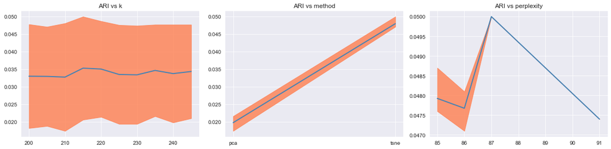

```
Meilleur résultat (0.05):

Matrice de confusion normalisée sur les 'true_labels' (en ligne):
```

|  | Baby Care | Beauty and Personal Care | Computers | Home Decor & Festive Needs | Home Furnishing | Kitchen & Dining | Watches |
| --- | --- | --- | --- | --- | --- | --- | --- |
| Baby Care | 0.11 | 0.09 | 0.20 | 0.17 | 0.23 | 0.13 | 0.07 |
| Beauty and Personal Care | 0.11 | 0.21 | 0.11 | 0.05 | 0.05 | 0.25 | 0.21 |
| Computers | 0.07 | 0.08 | 0.14 | 0.03 | 0.06 | 0.46 | 0.16 |
| Home Decor & Festive Needs | 0.12 | 0.11 | 0.12 | 0.15 | 0.19 | 0.27 | 0.04 |
| Home Furnishing | 0.09 | 0.14 | 0.23 | 0.12 | 0.34 | 0.06 | 0.02 |
| Kitchen & Dining | 0.05 | 0.18 | 0.06 | 0.05 | 0.03 | 0.51 | 0.13 |
| Watches | 0.07 | 0.17 | 0.22 | 0.03 | 0.04 | 0.22 | 0.25 |

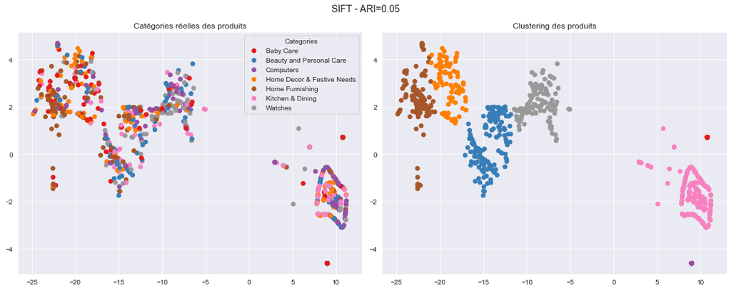

```
ARI = 0.05
```

```python
# Paramètres
paramGrid = {'k': np.arange(200, 250, 5),
             'method': ['tsne', 'pca']}

# Recherche
perplexity_range = np.arange(85, 125, 1)
#best_result = gridSearch(true_labels, paramGrid, func_sift,
#                         perplexity_range=perplexity_range,
#                         save='SIFT',
#                         verbose=False)

# Graphe de la recherche
filename = data_path + "SIFT.csv"
save = fig_path + "SIFT - search_graph.png"
best_result = search_graph(filename=filename, save=save, sep=';')

# Calcul des labels prédits du meilleur résultat
print(f"\nMeilleur résultat ({best_result[-1]}):")
perplexity = best_result[-2]

pred_labels, perplexity, X = func_sift(best_result,
                                      perplexity_range=[perplexity],
                                      get_X=True,
                                      verbose=False)

# Matrice de confusion
pred_labels = label_ordering(true_labels, pred_labels)

# Graphique de clustering
title = f"SIFT - ARI={best_result[-1]}"
filename = fig_path + "SIFT - Clustering.png"
visu(X, true_labels, pred_labels, perplexity=perplexity,
     legend=legend, title=title, save=filename)

# Vérification de l'évaluation du clustering
ari = eval_ARI(true_labels, pred_labels)
print(f"\nARI = {ari}")
```

*retour sommaire*

## 12 - Approche CV avec CNN

Dans cette approche, nous utilisons des modèles pré-entrainé afin de produire les features caractéristiques des images de notre projet (transfer learning) et effectuer le clustering avec ces features. Cette approche donne des résultats probants.

### 12.1 - Fonction d'extraction des features à partir d'un modèle pré-entrainé

```python
# Preprocessing et récupération des features
from keras.utils import load_img, img_to_array
from keras.applications.vgg16 import preprocess_input as preprocess_vgg16
from keras.applications.vgg19 import preprocess_input as preprocess_vgg19
from keras.applications.xception import preprocess_input as preprocess_xp
from keras.applications.efficientnet import preprocess_input as preprocess_en
from keras.applications.inception_resnet_v2 import preprocess_input as preprocess_rn2
import os.path as path

image_path = './P6_data/Flipkart/Images/'

def feature_extraction(model_name, model, feat_filename=None, verbose=False):
    # Récupération des features depuis le fichier s'il existe
    if (feat_filename is not None) and (path.exists(feat_filename)):
        if verbose: print(f"Récupération des features depuis le fichier {feat_filename}")
        file = np.load(feat_filename)
        features = np.asarray(file['features_cnn'])
        file.close()

    # Extraction des features sinon
    else:
        features = []
        for iname in tqdm(data_fk['image'].values.tolist(), desc="Preprocessing images"):

            # Chargement de l'image
            filename = image_path + iname
            if model_name=='VGG16' or model_name=='VGG19' or model_name=='EfficientNetB7':
                img_input_size = (224, 224)
            elif model_name=='Xception' or model_name=='InceptionResNetV2':
                img_input_size = (299, 299)
            img = load_img(filename, target_size=img_input_size)
            img = img_to_array(img)

            # Creation de la collection d'images (ici un seul échantillon à la fois)
            img = img.reshape((1, img.shape[0], img.shape[1], img.shape[2]))

            # Preprocessing de l'image
            if model_name=='VGG16':
                img = preprocess_vgg16(img)
            elif model_name=='VGG19':
                img = preprocess_vgg19(img)
            elif model_name=='Xception':
                img = preprocess_xp(img)
            elif model_name=='EfficientNetB7':
                img = preprocess_en(img)
            elif model_name=='InceptionResNetV2':
                img = preprocess_rn2(img)

            # Prédiction pour obtenir les features
            feature_img = model.predict(img)

            # Aplatissement pour former un vecteur
            feature_img = feature_img.reshape(-1)

            # Constitution progressive de la matrice des features
            features.append(feature_img)

        features = np.asarray(features)
        np.savez(feat_filename, features_cnn=features)
        if verbose: print(f"Sauvegarde des features dans le fichier {feat_filename}")

    return features
```

*retour sommaire*

### 12.2 - Fonction pour la recherche sur grille

```python
# Fonction utilisée par la recherche sur grille
from keras.applications import VGG16, VGG19, Xception, EfficientNetB7, InceptionResNetV2
def func_cnn(values, perplexity_range=[30], verbose=False, get_X=False):

    # Affectation des variables
    model_name = values[0]

    # Chargement du modèle pré-entrainé
    if model_name=='VGG16':
        model = VGG16(weights="imagenet", include_top=False, input_shape=(224, 224, 3))

    elif model_name=='VGG19':
        model = VGG19(weights="imagenet", include_top=False, input_shape=(224, 224, 3))

    elif model_name=='Xception':
        model = Xception(weights="imagenet", include_top=False, input_shape=(299, 299, 3))

    elif model_name=='EfficientNetB7':
        model = EfficientNetB7(weights="imagenet", include_top=False, input_shape=(224, 224, 3))

    elif model_name=='InceptionResNetV2':
        model = InceptionResNetV2(weights="imagenet", include_top=False, input_shape=(299, 299, 3))

    else:
        if get_X: return pred_labels, perplexity, X
        else: return pred_labels, perplexity

    if verbose: model.summary()

    # Extraction des features
    filename = data_path + model_name + "CNN_features.npz"
    feature_matrix = feature_extraction(model_name, model, feat_filename=filename, verbose=verbose)

    # Réduction de la dimensionnalité et clustering
    return label_predict(feature_matrix, method='tsne', perplexity=perplexity_range,
                         n_clusters=n_clusters, get_X=get_X, verbose=verbose)
```

*retour sommaire*

### 12.3 - Clustering avec recherche sur grille

```
Lecture des données depuis le fichier ./P6_data/Flipkart/CNN.csv
Paramètres du meilleur résultat (0.5031)
```

```
model         EfficientNetB7
perplexity                66
Name: 0, dtype: object
```

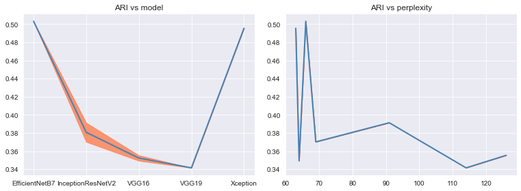

```
Meilleur résultat (0.5031):

Matrice de confusion normalisée sur les 'true_labels' (en ligne):
```

|  | Baby Care | Beauty and Personal Care | Computers | Home Decor & Festive Needs | Home Furnishing | Kitchen & Dining | Watches |
| --- | --- | --- | --- | --- | --- | --- | --- |
| Baby Care | 0.56 | 0.03 | 0.00 | 0.13 | 0.25 | 0.03 | 0.01 |
| Beauty and Personal Care | 0.03 | 0.78 | 0.01 | 0.09 | 0.05 | 0.05 | 0.00 |
| Computers | 0.09 | 0.03 | 0.61 | 0.17 | 0.05 | 0.06 | 0.00 |
| Home Decor & Festive Needs | 0.05 | 0.05 | 0.00 | 0.69 | 0.07 | 0.11 | 0.03 |
| Home Furnishing | 0.05 | 0.01 | 0.02 | 0.07 | 0.84 | 0.01 | 0.00 |
| Kitchen & Dining | 0.05 | 0.07 | 0.03 | 0.12 | 0.01 | 0.73 | 0.00 |
| Watches | 0.00 | 0.00 | 0.00 | 0.01 | 0.01 | 0.01 | 0.97 |

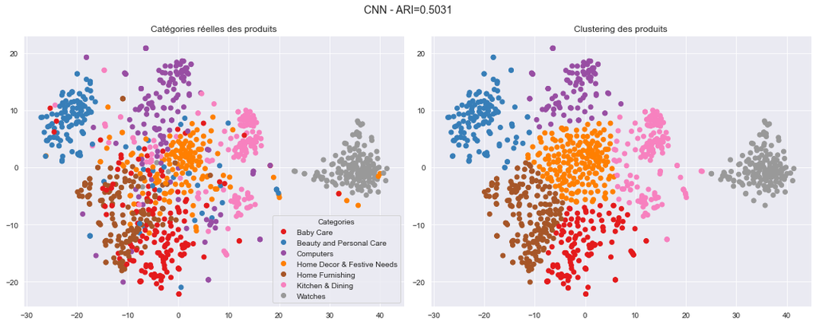

```
ARI = 0.5031
```

```python
# Paramètres
paramGrid = {'model': ['VGG16', 'VGG19', 'Xception', 'EfficientNetB7', 'InceptionResNetV2']}

# Recherche
perplexity_range = np.arange(60, 70, 1)
#best_result = gridSearch(true_labels, paramGrid, func_cnn, perplexity_range=perplexity_range, save='CNN', verbose=True)

# Graphe de la recherche
filename = data_path + "CNN.csv"
save = fig_path + "CNN - search_graph.png"
best_result = search_graph(filename=filename, save=save, sep=';')

# Calcul des labels prédits du meilleur résultat
print(f"\nMeilleur résultat ({best_result[-1]}):")
perplexity = best_result[-2]

pred_labels, perplexity, X = func_cnn(best_result,
                                      perplexity_range=[perplexity],
                                      get_X=True,
                                      verbose=False)

# Matrice de confusion
pred_labels = label_ordering(true_labels, pred_labels)

# Graphique de clustering
title = f"CNN - ARI={best_result[-1]}"
filename = fig_path + "CNN - Clustering.png"
visu(X, true_labels, pred_labels, perplexity=perplexity,
     legend=legend, title=title, save=filename)

# Vérification de l'évaluation du clustering
ari = eval_ARI(true_labels, pred_labels)
print(f"\nARI = {ari}")
```

*retour sommaire*

## 13 - Conclusion sur le clustering des images

La table ci-après donne le résumé des 2 approches utilisées pour le clustering des images, montrant clairement que seule l'approche CNN est probante.

```python
conclusion = {'Approche': [], 'Modele': [], 'ARI': [], 'Clustering': [], 'Recherche': []}
approaches = ['SIFT', 'CNN']

for approach in approaches:
    # Fichiers liés
    datafile = data_path + approach + ".csv"
    figclust = fig_path + f"{approach} - Clustering.png"
    figsearch = fig_path + f"{approach} - search_graph.png"

    # Récupération du meilleur résultat
    df_result = pd.read_csv(datafile, sep=';')
    df_result = df_result.drop_duplicates(ignore_index=True)
    best_result = df_result.sort_values(by='ARI', ascending=False, ignore_index=True).iloc[0]

    # Renseignement du dictionnaire
    conclusion['Approche'].append(approach)
    if approach=='SIFT':
        conclusion['Modele'].append(None)
    else:
        conclusion['Modele'].append(best_result[0])
    conclusion['ARI'].append(best_result[-1])
    conclusion['Clustering'].append(figclust)
    conclusion['Recherche'].append(figsearch)

# Conversion du dictionnaire en dataframe
df_result = pd.DataFrame.from_dict(conclusion)
df_result.sort_values(by='ARI', ascending=False, ignore_index=True, inplace=True)

# Affichage du dataframe des résultats avec fichiers graphiques clickables
import os
def make_link(filename):
    url = os.path.basename(filename)
    return f"<a target='_blank' href='{filename}'>{url}</a>"

display(df_result.style.format({'Clustering': make_link, 'Recherche': make_link}, precision=2))

# Sauvegarde du résultat dans un fichier csv
filename = data_path + "Image clustering results.csv"
df_result.to_csv(filename, sep=';', index=False)
```

|  | Approche | Modele | ARI | Clustering | Recherche |
| --- | --- | --- | --- | --- | --- |
| 0 | CNN | EfficientNetB7 | 0.50 | CNN - Clustering.png | CNN - search_graph.png |
| 1 | SIFT | None | 0.05 | SIFT - Clustering.png | SIFT - search_graph.png |

*retour sommaire*

## 14 - Clustering combiné du texte et des images

Nous disposons des clustering effectués à partir de l'analyse du texte et de celle effectuée sur les images. Nous nous interrogeons donc naturellement sur la possibilité de combiner ces clustering pour obtenir un résultat encore meilleur. Pour cela, nous explorons dans ce chapitre plusieurs approches de combinaison des analyses précédentes.

### 14.1 - Récupération des features des meilleurs modèles

Le clustering s'effectuant sur la base des features caractérisant les descriptifs textuels et les images, nous récupérons donc les features correspondant aux meilleurs modèles issus de l'analyse textuelle et de l'analyse computer vision.

```python
# Features de texte et d'image des meilleurs modèles
features_filename = data_path + "img_features.npz"
import os.path as path
if path.exists(features_filename):
    # Récupération des features depuis le fichier
    print(f"Récupération des features depuis le fichier {features_filename}")
    img_feat_file = np.load(features_filename)
    text_features = img_feat_file['text_features']
    img_features = img_feat_file['img_features']
    img_feat_file.close()

else:
    # Récupération des features de texte
    filename = data_path + "TfidfVectorizer.csv"
    best_result = search_graph(filename=filename, save=None, sep=';')
    p = best_result[-2]
    pl, p, text_features = func_vectorizer(best_result,
                                           perplexity_range=[p],
                                           language='english',
                                           get_X=True,
                                           verbose=False)

    # Récupération des features d'image
    filename = data_path + "CNN.csv"
    best_result = search_graph(filename=filename, save=None, sep=';')
    p = best_result[-2]
    pred_labels, p, img_features = func_cnn(best_result,
                                            perplexity_range=[p],
                                            get_X=True,
                                            verbose=False)

    # Sauvegarde des descripteurs
    np.savez(features_filename, text_features=text_features, img_features=img_features)
```

```
Récupération des features depuis le fichier ./P6_data/Flipkart/img_features.npz
```

*retour sommaire*

### 14.2 - Combinaison par concaténation des features

Dans cette approche, nous concatenons les features provenant de l'analyse textuelle avec celles provenant du computer vision. Nous utilisons pour cela 3 paramètres :

- le redimensionnement (ou pas) des vecteurs des 2 origines pour leur donner la même taille,
- l'affectation d'un poids relatif sur les features des 2 origines,
- la normalisation (ou pas) du vecteur résultant.

```python
def concatenate_features(tfeat, ifeat, normalize=True, redim=False, weight=0.5, verbose=False):
    # Redimensionnement
    if redim:
        dim = min(tfeat.shape[1], ifeat.shape[1], len(tfeat))
        print(f"dim={dim}")
        from sklearn.decomposition import PCA
        pca = PCA(n_components=dim, random_state=0)
        if ifeat.shape[1] > dim:
            ifeat = pca.fit_transform(ifeat)
            if verbose:
                print(f"Redimensionnement des features de CV de {img_features.shape} vers {ifeat.shape}")
                print(f"Variance expliquée: {100*pca.explained_variance_ratio_.sum():.1f}%")
        if tfeat.shape[1] > dim:
            tfeat = pca.fit_transform(tfeat)
            if verbose:
                print(f"Redimensionnement des features de texte de {text_features.shape} vers {tfeat.shape}")
                print(f"Variance expliquée: {100*pca.explained_variance_ratio_.sum():.1f}%")

    # Concaténation pondérée des features
    tfeat = weight * tfeat
    ifeat = (1 - weight) * ifeat
    features = np.concatenate([tfeat, ifeat], axis=1)

    # Normalisation euclidienne
    if normalize:
        from numpy import linalg as LA
        for i in range(len(features)):
            features[i] = features[i] / LA.norm(features[i])

    if verbose:
        print(f"Concaténation de {text_features.shape} features de texte pondérées "
              f"de {weight:.2f} et de {img_features.shape} features d'images pondérées "
              f"de {(1-weight):.2f} pour former {features.shape} features")

    return features
```

```python
# Fonction utilisée par la recherche sur grille
def func_mix(values, perplexity_range=[30], verbose=False, get_X=False):

    # Affectation des variables
    redim = values[0]
    normalize = values[1]
    weight = values[2]

    # Calcul des features
    features = concatenate_features(text_features, img_features, normalize=normalize, redim=redim, weight=weight, verbose=verbose)

    # Réduction de la dimensionnalité et clustering
    return label_predict(features, method='tsne', perplexity=perplexity_range,
                         n_clusters=n_clusters, get_X=get_X, verbose=verbose)
```

```
Lecture des données depuis le fichier ./P6_data/Flipkart/MIX.csv
Paramètres du meilleur résultat (0.6936)
```

```
redim          True
normalize     False
weight         1.00
perplexity       20
Name: 0, dtype: object
```

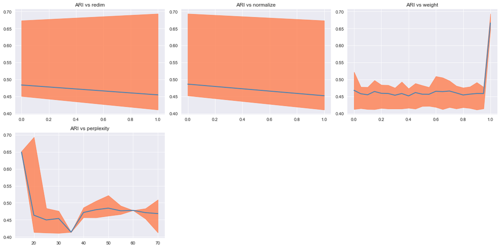

```python
# Paramètres
paramGrid = {'redim': [False, True],
             'normalize': [False, True],
             'weight': np.linspace(0, 1, 21)}

# Recherche
perplexity_range = np.arange(15, 71, 5)
#best_result = gridSearch(true_labels, paramGrid, func_mix, perplexity_range=perplexity_range, save='MIX', verbose=True)

# Graphe de la recherche
filename = data_path + "MIX.csv"
save = fig_path + "MIX - search_graph.png"
best_result = search_graph(filename=filename, save=save, sep=';')
```

*retour sommaire*

### 14.3 - Combinaison des probabilités de label des modèles

Dans cette approche, nous cherchons à combiner le résultat de chaque analyse (NLP et CV), chacun exprimé sous la forme de probabilité d'appartenance aux clusters, afin de maximiser le taux de succès des labels prédits par rapport aux labels vrais.

Pour cela, nous utilisons 2 modèles de mélange gaussien, un pour l'analyse NLP et l'autre pour l'analyse CV. Cela nous fournit 2 jeux de probabilité d'appartenance aux clusters que nous combinons de 3 manières différentes :

- le label prédit correspond au maximum de probabilité sur l'ensemble des clusters et pour les 2 analyses ;
- le label prédit correspond au maximum de la somme des probabilités par cluster sur les 2 analyses ;
- le label prédit correspond au maximum du produit des probabilités par cluster sur les 2 analyses.

Les 3 résultats de cette approche sont très proches et de bon niveau. Cependant, cette approche n'a pas permis d'améliorer le meilleur résultat individuel (NLP). Il a en revanche montré que le recoupement des clustering effectués à partir du texte et des images peut être consolidé de manière à fiabiliser le résultat.

#### A - Prédiction des probabilités d'appartenance aux catégories pour les 2 modèles

```python
# Prédiction des probabilités d'appartenance aux catégories pour les 2 modèles
from sklearn.mixture import GaussianMixture

# Recherche du meilleur modèle GMM pour le texte
perplexity_range = np.arange(5, 20)
ari_text = -1
for perplexity in tqdm(perplexity_range, desc='Calcul de perplexity pour NLP'):
    Xt = dim_reduction(text_features, method='tsne', perplexity=perplexity)
    gmm_text = GaussianMixture(n_components=n_clusters, random_state=0)
    gmm_text.fit(Xt)
    pl_text = gmm_text.predict(Xt)
    ari = eval_ARI(true_labels, pl_text)
    if ari > ari_text:
        ari_text = ari
        perplexity_text = perplexity

# Prédiction avec le meilleur modèle
Xt = dim_reduction(text_features, method='tsne', perplexity=perplexity_text)
gmm_text = GaussianMixture(n_components=n_clusters, random_state=0)
gmm_text.fit(Xt)
pl_text = gmm_text.predict(Xt)

# Mapper pour faire correspondre le clustering avec les catégories
text_mapper = label_ordering(true_labels, pl_text, get_mapper=True)
pl_text = np.asarray([text_mapper.index(int(i)) for i in pl_text])

# Prédiction des probabilités de label avec les descriptions textuelles
pred_labels_text_matrix = gmm_text.predict_proba(Xt)
pred_labels_text_matrix[:] = pred_labels_text_matrix[:, text_mapper]
ari_text = eval_ARI(true_labels, pl_text)
print(f"Prédiction avec NLP - ARI={ari_text:.2f} - Perplexity={perplexity_text} :")
pd.options.display.float_format = '{:,.2f}'.format
text_col = ["txt_" + cat.replace(" ", "")[:5] for cat in legend]
df_txt = pd.DataFrame(pred_labels_text_matrix, columns=text_col)
display(df_txt.head(5))
```

```
Prédiction avec NLP - ARI=0.65 - Perplexity=12 :
```

|  | txt_BabyC | txt_Beaut | txt_Compu | txt_HomeD | txt_HomeF | txt_Kitch | txt_Watch |
| --- | --- | --- | --- | --- | --- | --- | --- |
| 0 | 0.00 | 0.00 | 0.00 | 0.20 | 0.72 | 0.07 | 0.00 |
| 1 | 0.91 | 0.00 | 0.00 | 0.09 | 0.00 | 0.00 | 0.00 |
| 2 | 0.92 | 0.00 | 0.00 | 0.08 | 0.01 | 0.00 | 0.00 |
| 3 | 0.00 | 0.00 | 0.00 | 0.00 | 0.97 | 0.03 | 0.00 |
| 4 | 0.00 | 0.00 | 0.00 | 0.00 | 0.97 | 0.03 | 0.00 |

```python
# Recherche du meilleur modèle GMM pour les images
perplexity_range = np.arange(2, 10)
ari_img = -1
for perplexity in tqdm(perplexity_range, desc='Calcul de perplexity pour CV'):
    Xi = dim_reduction(img_features, method='tsne', perplexity=perplexity)
    gmm_img = GaussianMixture(n_components=n_clusters, random_state=0)
    gmm_img.fit(Xi)
    pl_img = gmm_img.predict(Xi)
    ari = eval_ARI(true_labels, pl_img)
    if ari > ari_img:
        ari_img = ari
        perplexity_img = perplexity

# Prédiction avec le meilleur modèle
Xi = dim_reduction(img_features, method='tsne', perplexity=perplexity_img)
gmm_img = GaussianMixture(n_components=n_clusters, random_state=0)
gmm_img.fit(Xi)
pl_img = gmm_img.predict(Xi)

# Mapper pour faire correspondre le clustering avec les catégories
img_mapper = label_ordering(true_labels, pl_img, get_mapper=True)
pl_img = np.asarray([img_mapper.index(int(i)) for i in pl_img])

# Prédiction des probabilités de label avec les images
pred_labels_img_matrix = gmm_img.predict_proba(Xi)
pred_labels_img_matrix[:] = pred_labels_img_matrix[:, img_mapper]
ari_img = eval_ARI(true_labels, pl_img)
print(f"Prédiction avec CV - ARI={ari_img:.2f} - Perplexity={perplexity_img} :")
img_col = ["img_" + cat.replace(" ", "")[:5] for cat in legend]
df_img = pd.DataFrame(pred_labels_img_matrix, columns=img_col)
display(df_img.head(5))
```

```
Prédiction avec CV - ARI=0.49 - Perplexity=6 :
```

|  | img_BabyC | img_Beaut | img_Compu | img_HomeD | img_HomeF | img_Kitch | img_Watch |
| --- | --- | --- | --- | --- | --- | --- | --- |
| 0 | 0.00 | 0.00 | 0.00 | 0.00 | 1.00 | 0.00 | 0.00 |
| 1 | 1.00 | 0.00 | 0.00 | 0.00 | 0.00 | 0.00 | 0.00 |
| 2 | 1.00 | 0.00 | 0.00 | 0.00 | 0.00 | 0.00 | 0.00 |
| 3 | 0.02 | 0.00 | 0.00 | 0.00 | 0.98 | 0.00 | 0.00 |
| 4 | 0.24 | 0.00 | 0.00 | 0.01 | 0.75 | 0.00 | 0.00 |

#### B - Complémentarité des prédictions des 2 modèles

```python
# Table des labels vrais et prédits pour chaque échantillon
df = np.full((len(true_labels), 3), -1)
df[:,0] = true_labels
df[:,1] = pl_text
df[:,2] = pl_img
df = pd.DataFrame(df, columns=['label_true', 'text_pred', 'img_pred'])

# Grandeurs caractéristiques
df['text_ok'] = (df['text_pred']==df['label_true'])
df['img_ok'] = (df['img_pred']==df['label_true'])
df['same_ok'] = df['text_ok'] & df['img_ok']
df['same_nok'] = ~df['text_ok'] & ~df['img_ok']
df['compl'] = (df['text_ok'] | df['img_ok']) & (~df['text_ok'] | ~df['img_ok'])
df['compl_text_ok'] = df['compl'] & df['text_ok']
df['compl_img_ok'] = df['compl'] & df['img_ok']
text_hit = df['text_ok'].sum() / len(df)
img_hit = df['img_ok'].sum() / len(df)
same_ok = df['same_ok'].sum() / len(df)
same_nok = df['same_nok'].sum() / len(df)
compl = df['compl'].sum() / len(df)
compl_text_ok = df['compl_text_ok'].sum() / len(df)
compl_img_ok = df['compl_img_ok'].sum() / len(df)

# Affichage des taux
print(f"→ Taux de succès pour le clustering avec NLP: {100*text_hit:.1f}%")
print(f"→ Taux de succès pour le clustering avec CV : {100*img_hit:.1f}%")
print(f"→ Taux de succès commun : {100*same_ok:.1f}%")
print(f"→ Taux d'insuccès commun : {100*same_nok:.1f}%")
print(f"→ Taux de complémentarité: {100*compl:.1f}%, "
      f"dont {100*compl_text_ok:.1f}% OK pour NLP et {100*compl_img_ok:.1f}% OK pour CV")
```

```
→ Taux de succès pour le clustering avec NLP: 83.0%
→ Taux de succès pour le clustering avec CV : 71.7%
→ Taux de succès commun : 66.2%
→ Taux d'insuccès commun : 11.4%
→ Taux de complémentarité: 22.4%, dont 16.9% OK pour NLP et 5.5% OK pour CV
```

#### C - Prédiction du label selon le maximum des prédictions

```python
# Prédiction du label selon le maximum des prédictions
df_pred = pd.concat([df_txt, df_img], axis=1)
#display(df_pred[:10])
df['pl_max'] = np.argmax(df_pred.values, axis=1) % n_clusters

# Hit rate de la prédiction
df['pl_max_ok'] = df['pl_max']==df['label_true']
pl_max_hit = df['pl_max_ok'].sum() / len(df)
print(f"→ Taux de succès de la stratégie du maximum des prédictions: {100*pl_max_hit:.1f}%")

# ARI
ari = eval_ARI(true_labels, df['pl_max'].values, verbose=True)
```

```
→ Taux de succès de la stratégie du maximum des prédictions: 79.0%
ARI =  0.5977
```

#### D - Prédiction du label selon le maximum de la somme des prédictions

```python
# Prédiction du label selon le maximum de la somme des prédictions
df_pred = df_txt.values + df_img.values
#display(df_pred[:10])
df['pl_sum_max'] = np.argmax(df_pred, axis=1)

# Hit rate de la prédiction
df['pl_sum_max_ok'] = df['pl_sum_max']==df['label_true']
pl_sum_max_hit = df['pl_sum_max_ok'].sum() / len(df)
print(f"→ Taux de succès de la stratégie du maximum de la somme des prédictions: {100*pl_sum_max_hit:.1f}%")

# ARI
ari = eval_ARI(true_labels, df['pl_sum_max'].values, verbose=True)
```

```
→ Taux de succès de la stratégie du maximum de la somme des prédictions: 78.9%
ARI =  0.594
```

#### E - Prédiction du label selon le maximum du produit des prédictions

```python
# Prédiction du label selon le maximum du produit des prédictions
df_pred = np.multiply(df_txt.values, df_img.values)
#display(df_pred[:10])
df['pl_prod_max'] = np.argmax(df_pred, axis=1)

# Hit rate de la prédiction
df['pl_prod_max_ok'] = df['pl_prod_max']==df['label_true']
pl_prod_max_hit = df['pl_prod_max_ok'].sum() / len(df)
print(f"→ Taux de succès de la stratégie du maximum du produit des prédictions: {100*pl_prod_max_hit:.1f}%")

# ARI
ari = eval_ARI(true_labels, df['pl_prod_max'].values, verbose=True)
```

```
→ Taux de succès de la stratégie du maximum du produit des prédictions: 80.3%
ARI =  0.5937
```

*retour sommaire*

## 15 - Conclusion sur le projet

L'objet de ce projet est d'examiner la faisabilité de classifier de manière non supervisée la liste des produits d'un site de e-commerce à partir de leur description sous forme de texte ou d'image.

**Les résultats des clustering effectués dans ces 2 domaines montrent clairement cette faisabilité.**

S'agissant de l'analyse du texte, l'approche la plus performante est aussi la plus simple le 'bag of words'. S'agissant de l'analyse des images, l'approche la plus performante s'appuie sur les modèles pré-entrainés de réseau de neurones convolutifs ; cette approche peut sembler d'un abord complexe, mais sa mise en œuvre est très simple.

*retour sommaire*